# Water Column and Sediment Methanogens & Methanotrophs in FPV Ponds

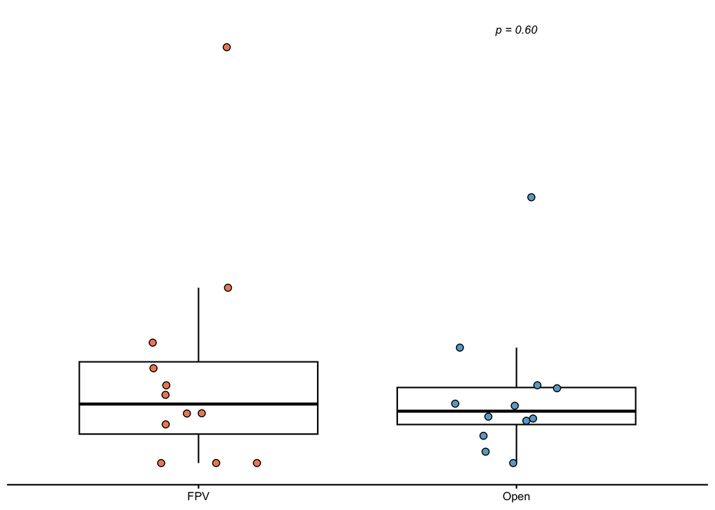

```r
# 3. box plot
methanogen_surface_box <- methanogen_surface_data %>%
  ggplot(aes(x = solar_progress, y = total_abundance, color = solar_progress)) +
  geom_boxplot(outlier.shape = NA, color = "black") +
  geom_jitter(aes(color = solar_progress, fill = solar_progress), width = 0.2, size = 2, shape = 21) +
  scale_fill_manual(values = solar_colors)+
  scale_color_manual(values = c("black", "black"))+
  scale_y_continuous(
    limits = c(NA, 6000),
    #breaks = c(0, 2500, 5000, 7500),
     breaks = c(0, 3000, 6000),
    labels = label_number(scale_cut = cut_short_scale())) +
  theme_classic()+
  theme(axis.text.x = element_text(size = 8,colour = "black"),
        axis.title.x = element_blank(),
        axis.title.y = element_blank(),
        axis.line.y = element_blank(),
        axis.text.y = element_blank(),
        axis.ticks.y = element_blank(),
        legend.position = "none") +
 annotate("text", x = 2, y = 6000, label = "p = 0.60", size = 2.822,  fontface = "italic") #.6033
methanogen_surface_box
```

```r
##### surface methanotrophs #####
# 1. calculate stats
# 1a. calculate abundances
methanotroph_surface_sum <- water_ch4_cyclers_df %>%
  dplyr::filter(Depth_Class == "Surface Water",
                CH4_Cycler == "Methanotroph") %>%
  group_by(solar_progress, JDate) %>%
  dplyr::summarize(sd_meth = sd(total_abundance),
                   mean_meth = mean(total_abundance), # max does exceed 1mil
                   .groups = "drop")
methanotroph_surface_sum
```

```
## # A tibble: 8 × 4
##   solar_progress JDate sd_meth mean_meth
##   <fct>          <dbl>   <dbl>     <dbl>
## 1 FPV              172  13014.    46784.
## 2 FPV              193 115883.   154147.
## 3 FPV              234 152940.   354579.
## 4 FPV              255 314547.   676476
## 5 Open             172   6211.    12978
## 6 Open             193  45921.    85024.
## 7 Open             234  50089.   134331.
## 8 Open             255  70960.    65802.
```

```r
max(methanotroph_surface_sum$mean_meth)
```

```
## [1] 676476
```

```r
# calculate abundances between treatments
methanotroph_surface_sum_text <- water_ch4_cyclers_df %>%
  dplyr::filter(Depth_Class == "Surface Water",
                CH4_Cycler == "Methanotroph") %>%
  group_by(solar_progress, JDate) %>%
  dplyr::summarize(sd_meth = sd(total_abundance),
                   mean_meth = mean(total_abundance),
                   .groups = "drop")
methanotroph_surface_sum_text
```

```
## # A tibble: 8 × 4
##   solar_progress JDate sd_meth mean_meth
##   <fct>          <dbl>   <dbl>     <dbl>
## 1 FPV              172  13014.    46784.
## 2 FPV              193 115883.   154147.
## 3 FPV              234 152940.   354579.
## 4 FPV              255 314547.   676476
## 5 Open             172   6211.    12978
## 6 Open             193  45921.    85024.
## 7 Open             234  50089.   134331.
## 8 Open             255  70960.    65802.
```

```r
max(methanotroph_surface_sum_text$mean_meth)
```

```
## [1] 676476
```

```r
# 1b. linear mixed model
methanotroph_surface_data <- water_ch4_cyclers_df %>%
  dplyr::filter(Depth_Class == "Surface Water",
                CH4_Cycler == "Methanotroph")
methanotroph_surface_data$Pond <- as.factor(methanotroph_surface_data$Pond)

max(methanotroph_surface_data$total_abundance/1e6)
```

```
## [1] 1.027419
```

```r
surface_methanotroph_model <- lmer(total_abundance ~ solar_progress + JDate + (1|Pond), data = methanotroph_surface_data)
summary(surface_methanotroph_model) # 0.000924 ***
```

```
## Linear mixed model fit by REML. t-tests use Satterthwaite's method ['lmerModLmerTest']
## Formula: total_abundance ~ solar_progress + JDate + (1 | Pond)
##    Data: methanotroph_surface_data
##
## REML criterion at convergence: 580.7
##
## Scaled residuals:
##     Min      1Q  Median      3Q     Max
## -1.2753 -0.6016 -0.2559  0.5651  3.2658
##
## Random effects:
##  Groups   Name        Variance  Std.Dev.
##  Pond     (Intercept) 0.000e+00      0
##  Residual             2.914e+10 170698
## Number of obs: 24, groups:  Pond, 6
##
## Fixed effects:
##                      Estimate Std. Error         df t value Pr(>|t|)
## (Intercept)        -5.252e+05  2.326e+05  5.177e+36  -2.258 0.023935 *
## solar_progressOpen -2.335e+05  6.969e+04  5.177e+36  -3.350 0.000808 ***
## JDate               3.902e+03  1.065e+03  5.177e+36   3.666 0.000247 ***
## ---
## Signif. codes:  0 '***' 0.001 '**' 0.01 '*' 0.05 '.' 0.1 ' ' 1
##
## Correlation of Fixed Effects:
##             (Intr) slr_pO
## slr_prgrssO -0.150
## JDate       -0.977  0.000
## optimizer (nloptwrap) convergence code: 0 (OK)
## boundary (singular) fit: see help('isSingular')
```

```r
emmeans::emmeans(surface_methanotroph_model, pairwise ~ solar_progress) # 0.0296
```

```
## $emmeans
##  solar_progress emmean    SE df lower.CL upper.CL
##  FPV            307997 49300  4   171183   444810
##  Open            74534 49300  4   -62279   211347
##
## Degrees-of-freedom method: kenward-roger
## Confidence level used: 0.95
##
## $contrasts
##  contrast   estimate    SE df t.ratio p.value
##  FPV - Open   233463 69700  4   3.350  0.0286
##
## Degrees-of-freedom method: kenward-roger
```

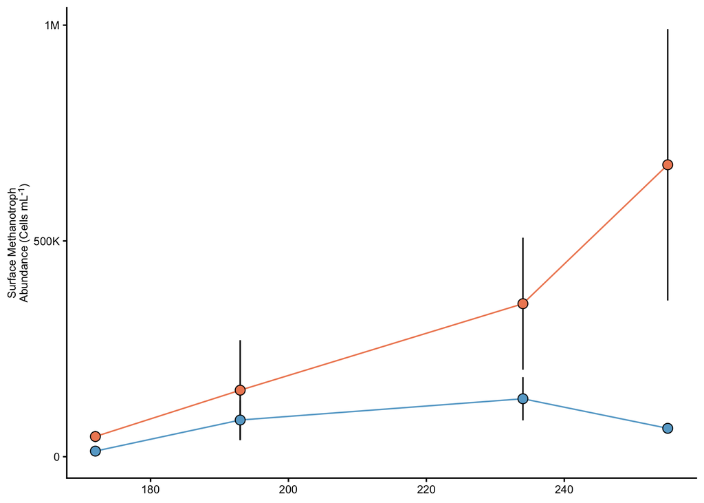

```r
# 2. plot surface water methanotrophs
methanotroph_surface <- methanotroph_surface_sum %>%
  ggplot(aes(x = JDate, y = mean_meth, fill = solar_progress, color = solar_progress)) +
  #geom_smooth(aes(group = solar_progress), se = FALSE) +
  geom_line()+
  geom_point()+
  theme_classic()+
  geom_errorbar(aes(x = JDate, ymin = mean_meth - sd_meth, ymax = mean_meth + sd_meth), width = 0, color = "black")+
  geom_point(size = 3, shape = 16)+
  geom_point(size = 3, shape = 1, color = "black") +
  labs(y= "Surface Methanotroph<br>Abundance (Cells mL<sup>-1</sup>)", x = "Day of Year")+
  scale_y_continuous(
    limits = c(0, NA),
    breaks = c(0, 5e5, 1e6),
    labels = c("0", "500K", "1M"))+
  # scale_y_continuous(
  #    limits = c(0, NA),
  #   # breaks = c(0, 7.5e5, 1.5e6),
  #   # labels = c("0", "750K", "1.5M"))+
    # labels = label_number(scale_cut = cut_short_scale())) +
    #labels = label_number(scale_cut = cut_short_scale(), accuracy = 0.01)) +
  theme(axis.text.x =  element_text(size = 8,colour = "black"),
         axis.text.y =  element_text(size = 8,colour = "black"),
         axis.title.x = element_blank(),
        axis.title.y = element_markdown(size = 8))+
  scale_fill_manual(values = solar_colors)+
  scale_color_manual(values = solar_colors)+
  theme(legend.position = "none")
methanotroph_surface
```

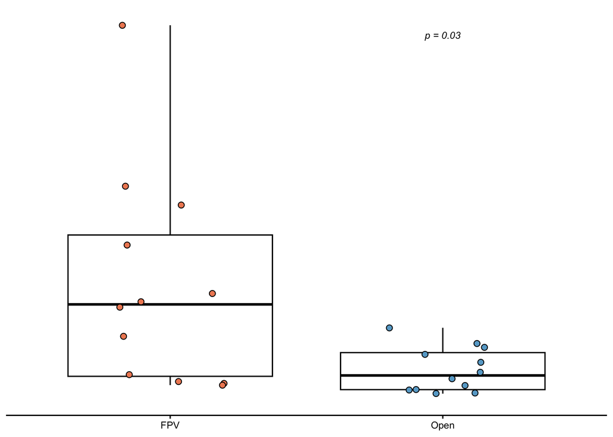

```r
# 3. box plot
methanotroph_surface_box <- methanotroph_surface_data %>%
  ggplot(aes(x = solar_progress, y = total_abundance, color = solar_progress)) +
  geom_boxplot(outlier.shape = NA, color = "black") +
  geom_jitter(aes(color = solar_progress, fill = solar_progress), width = 0.2, size = 2, shape = 21) +
  scale_fill_manual(values = solar_colors)+
  scale_color_manual(values = c("black", "black"))+
  scale_y_continuous(
    limits = c(0, NA),
    breaks = c(0, 5e5, 1e6),
    labels = c("0", "500K", "1M"))+
  # scale_y_continuous(
  #   limits = c(0, 1.27e6),
  #   breaks = c(0, 2.5e5, 7.5e5, 1.25e6),
  #   labels = c("0","250K", "750K", "1.25M"))+
  #   # breaks = c(0, 5e5, 1e6, 1.5e6),
  #   #labels = label_number(scale_cut = cut_short_scale())) +
  theme_classic()+
  theme(axis.text.x = element_text(size = 8,colour = "black"),
        axis.title.x = element_blank(),
        axis.title.y = element_blank(),
        axis.line.y = element_blank(),
        axis.text.y = element_blank(),
        axis.ticks.y = element_blank(),
        legend.position = "none") +
  # stat_compare_means(method = "wilcox.test",
  #                    #comparisons = list(c("FPV", "Open")),
  #                    label = "p.format",
  #                    size = 3,
  #                    label.y.npc = 0.9,
  #                    fontface = "italic")
  #label.y = c(8000, 100000, 500000, 400000, 400000), # get pvalue
 annotate("text", x = 2, y = 1e6, label = "p = 0.03", size = 2.822,  fontface = "italic") # add p value
methanotroph_surface_box
```

```r
##### bottom methanogens #####
# 1. statistics
# 1a. abundance stats
methanogen_bottom_sum <- water_ch4_cyclers_df %>%
  dplyr::filter(Depth_Class == "Bottom Water",
                CH4_Cycler == "Methanogen") %>%
  group_by(solar_progress, JDate) %>%
  dplyr::summarize(sd_meth = sd(total_abundance),
                   mean_meth = mean(total_abundance))
methanogen_bottom_sum
```

```
## # A tibble: 8 × 4
## # Groups:   solar_progress [2]
##   solar_progress JDate sd_meth mean_meth
##   <fct>          <dbl>   <dbl>     <dbl>
## 1 FPV              172   3950.     8308.
## 2 FPV              193   9307.    15281
## 3 FPV              234   1209.     4002.
## 4 FPV              255   3707.     7266.
## 5 Open             172  15699.    11104
## 6 Open             193   2948.    15425.
## 7 Open             234  43683.    30571.
## 8 Open             255   2068.     2356
```

```r
max(methanogen_bottom_sum$mean_meth)
```

```
## [1] 30570.67
```

```r
# 1b. linear mixed model
methanogen_bottom_data <- water_ch4_cyclers_df %>%
  dplyr::filter(Depth_Class == "Bottom Water",
                CH4_Cycler == "Methanogen")

methanogen_bottom_data$Pond <- as.factor(methanogen_bottom_data$Pond)

bottom_methanogen_model <- lmer(total_abundance ~ solar_progress + JDate + (1|Pond), data = methanogen_bottom_data)
summary(bottom_methanogen_model) # 0.536
```

```
## Linear mixed model fit by REML. t-tests use Satterthwaite's method ['lmerModLmerTest']
## Formula: total_abundance ~ solar_progress + JDate + (1 | Pond)
##    Data: methanogen_bottom_data
##
## REML criterion at convergence: 482.5
##
## Scaled residuals:
##     Min      1Q  Median      3Q     Max
## -1.2668 -0.3415 -0.1913  0.1340  3.7474
##
## Random effects:
##  Groups   Name        Variance  Std.Dev.
##  Pond     (Intercept)  64847986  8053
##  Residual             235745079 15354
## Number of obs: 24, groups:  Pond, 6
##
## Fixed effects:
##                    Estimate Std. Error       df t value Pr(>|t|)
## (Intercept)        16861.01   21429.49    19.71   0.787    0.441
## solar_progressOpen  6149.83    9084.21     4.00   0.677    0.536
## JDate                -38.16      95.76    17.00  -0.398    0.695
##
## Correlation of Fixed Effects:
##             (Intr) slr_pO
## slr_prgrssO -0.212
## JDate       -0.954  0.000
```

```r
emmeans::emmeans(bottom_methanogen_model, pairwise ~ solar_progress) # 0.5355
```

```
## $emmeans
##  solar_progress emmean   SE df lower.CL upper.CL
##  FPV              8714 6420  4    -9120    26549
##  Open            14864 6420  4    -2971    32699
##
## Degrees-of-freedom method: kenward-roger
## Confidence level used: 0.95
##
## $contrasts
##  contrast   estimate   SE df t.ratio p.value
##  FPV - Open    -6150 9080  4  -0.677  0.5355
##
## Degrees-of-freedom method: kenward-roger
```

```r
max(methanogen_bottom_data$total_abundance)
```

```
## [1] 80986
```

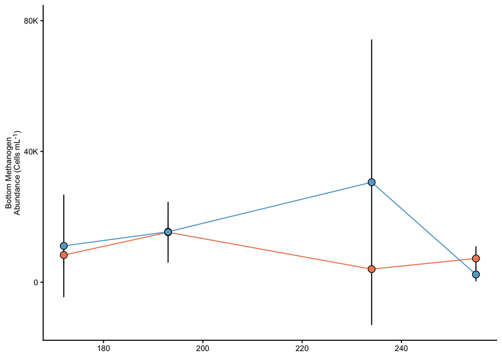

```r
# 2. plot bottom water methanogens overtime
methanogen_bottom <- methanogen_bottom_sum %>%
  ggplot(aes(x = JDate, y = mean_meth, fill = solar_progress, color = solar_progress)) +
  geom_line()+
  geom_point()+
  theme_classic()+
  geom_errorbar(aes(x = JDate, ymin = mean_meth - sd_meth, ymax = mean_meth + sd_meth), width = 0, color = "black") +
  geom_point(size = 3, shape = 16)+
  geom_point(size = 3, shape = 1, color = "black")+
  labs(y= "Bottom Methanogen<br>Abundance (Cells mL<sup>-1</sup>)", x = "Day of Year")+
  scale_y_continuous(
  limits = c(NA, 8e4),
  breaks = c(0, 4e4, 8e4),
    labels = label_number(scale_cut = cut_short_scale())) +
  theme(axis.text.x =  element_text(size = 8,colour = "black"),
         axis.text.y =  element_text(size = 8,colour = "black"),
         axis.title.x = element_blank(),
        axis.title.y = element_markdown(size = 8))+
  scale_fill_manual(values = solar_colors)+
  scale_color_manual(values = solar_colors) +
  theme(legend.position = "none")#+
  #scale_y_continuous(limits = c(0,11), breaks = c(0, 5, 10))+
  #scale_x_continuous(limits = c(170,250))
methanogen_bottom
```

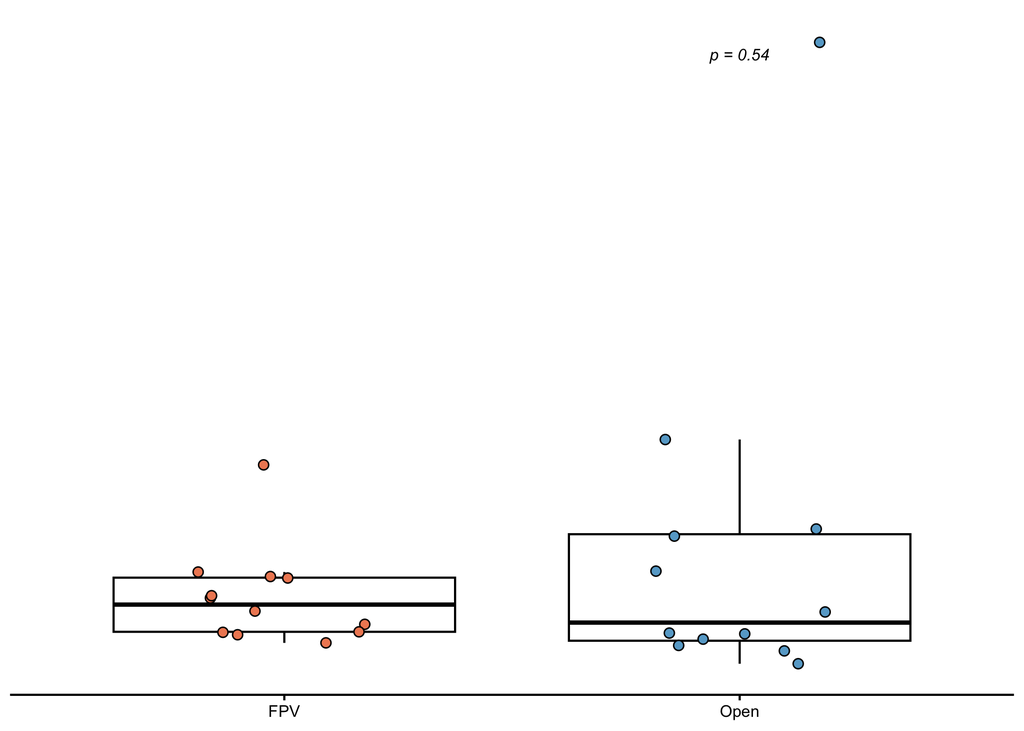

```r
# 3. box plot
methanogen_bottom_box <- methanogen_bottom_data %>%
  ggplot(aes(x = solar_progress, y = total_abundance, color = solar_progress)) +
  geom_boxplot(outlier.shape = NA, color = "black") +
  geom_jitter(aes(color = solar_progress, fill = solar_progress), width = 0.2, size = 2, shape = 21) +
  scale_fill_manual(values = solar_colors)+
  scale_color_manual(values = c("black", "black"))+
  scale_y_continuous(
  limits = c(NA, 8.1e4),
  breaks = c(0, 4e4, 8e4),
    labels = label_number(scale_cut = cut_short_scale())) +
  theme_classic()+
  theme(axis.text.x = element_text(size = 8,colour = "black"),
        axis.title.x = element_blank(),
        axis.title.y = element_blank(),
        axis.line.y = element_blank(),
        axis.text.y = element_blank(),
        axis.ticks.y = element_blank(),
        legend.position = "none") +
  # stat_compare_means(method = "wilcox.test",
  #                    #comparisons = list(c("FPV", "Open")),
  #                    label = "p.format",
  #                    size = 3,
  #                    label.y.npc = 0.9,
  #                    fontface = "italic")
                     #label.y = c(8000, 100000, 500000, 400000, 400000), # get pvalue
 annotate("text", x = 2, y = 7.94e4, label = "p = 0.54", size = 2.822,  fontface = "italic")
methanogen_bottom_box
```

```r
##### bottom water methanotrophs #####
# 1. statistics
# 1a. calculate abundance stats
methanotroph_bottom_sum <- water_ch4_cyclers_df %>%
  dplyr::filter(Depth_Class == "Bottom Water",
                CH4_Cycler == "Methanotroph") %>%
  group_by(solar_progress, JDate) %>%
  dplyr::summarize(sd_meth = sd(total_abundance),
                   mean_meth = mean(total_abundance))
methanotroph_bottom_sum
```

```
## # A tibble: 8 × 4
## # Groups:   solar_progress [2]
##   solar_progress JDate sd_meth mean_meth
##   <fct>          <dbl>   <dbl>     <dbl>
## 1 FPV              172  82213.   146429.
## 2 FPV              193 219991.   229929.
## 3 FPV              234 190811.   357040
## 4 FPV              255 420076.   565286.
## 5 Open             172  73065.   127291.
## 6 Open             193  33201.    86164
## 7 Open             234 116670.   170832.
## 8 Open             255  50276.    53339
```

```r
max(methanotroph_bottom_sum$mean_meth)
```

```
## [1] 565285.7
```

```r
# calculate abundances between treatments
methanotroph_bottom_sum_text <- water_ch4_cyclers_df %>%
  dplyr::filter(Depth_Class == "Bottom Water",
                CH4_Cycler == "Methanotroph") %>%
  group_by(solar_progress, JDate) %>%
  dplyr::summarize(sd_meth = sd(total_abundance),
                   mean_meth = mean(total_abundance),
                   .groups = "drop")
methanotroph_bottom_sum_text
```

```
## # A tibble: 8 × 4
##   solar_progress JDate sd_meth mean_meth
##   <fct>          <dbl>   <dbl>     <dbl>
## 1 FPV              172  82213.   146429.
## 2 FPV              193 219991.   229929.
## 3 FPV              234 190811.   357040
## 4 FPV              255 420076.   565286.
## 5 Open             172  73065.   127291.
## 6 Open             193  33201.    86164
## 7 Open             234 116670.   170832.
## 8 Open             255  50276.    53339
```

```r
max(methanotroph_bottom_sum_text$mean_meth)
```

```
## [1] 565285.7
```

```r
# 1b. linear mixed model
methanotroph_bottom_data <- water_ch4_cyclers_df %>%
  dplyr::filter(Depth_Class == "Bottom Water",
                CH4_Cycler == "Methanotroph")
methanotroph_bottom_data$Pond <- as.factor(methanotroph_bottom_data$Pond)

bottom_methanotroph_model <- lmerTest::lmer(total_abundance ~ solar_progress + JDate + (1|Pond), data = methanotroph_bottom_data)
summary(bottom_methanotroph_model) # 0.0679
```

```
## Linear mixed model fit by REML. t-tests use Satterthwaite's method ['lmerModLmerTest']
## Formula: total_abundance ~ solar_progress + JDate + (1 | Pond)
##    Data: methanotroph_bottom_data
##
## REML criterion at convergence: 585.8
##
## Scaled residuals:
##     Min      1Q  Median      3Q     Max
## -1.1969 -0.5777 -0.1677  0.4445  3.0592
##
## Random effects:
##  Groups   Name        Variance  Std.Dev.
##  Pond     (Intercept) 2.009e+09  44827
##  Residual             3.570e+10 188937
## Number of obs: 24, groups:  Pond, 6
##
## Fixed effects:
##                      Estimate Std. Error         df t value Pr(>|t|)
## (Intercept)        -1.401e+05  2.587e+05  1.349e+03  -0.541   0.5883
## solar_progressOpen -2.153e+05  8.538e+04  4.000e+00  -2.521   0.0653 .
## JDate               2.177e+03  1.178e+03  7.983e+17   1.847   0.0647 .
## ---
## Signif. codes:  0 '***' 0.001 '**' 0.01 '*' 0.05 '.' 0.1 ' ' 1
##
## Correlation of Fixed Effects:
##             (Intr) slr_pO
## slr_prgrssO -0.165
## JDate       -0.972  0.000
```

```r
emmeans::emmeans(bottom_methanotroph_model, pairwise ~ solar_progress) # 0.0679
```

```
## $emmeans
##  solar_progress emmean    SE df lower.CL upper.CL
##  FPV            324671 60400  4   157056   492286
##  Open           109406 60400  4   -58208   277022
##
## Degrees-of-freedom method: kenward-roger
## Confidence level used: 0.95
##
## $contrasts
##  contrast   estimate    SE df t.ratio p.value
##  FPV - Open   215265 85400  4   2.521  0.0653
##
## Degrees-of-freedom method: kenward-roger
```

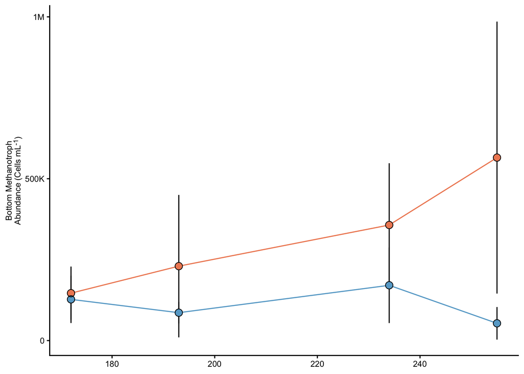

```r
# 2. plot bottom water methanotrophs
methanotroph_bottom <- methanotroph_bottom_sum %>%
  ggplot(aes(x = JDate, y = mean_meth, fill = solar_progress, color = solar_progress)) +
  geom_line()+
  geom_point()+
  theme_classic()+
  geom_errorbar(aes(x = JDate, ymin = mean_meth - sd_meth, ymax = mean_meth + sd_meth), width = 0, color = "black")+
  geom_point(size = 3, shape = 16)+
  geom_point(size = 3, shape = 1, color = "black")+
  labs(y= "Bottom Methanotroph<br>Abundance (Cells mL<sup>-1</sup>)", x = "Day of Year")+
  scale_y_continuous(
    breaks = c(0, 5e5, 1e6),
    labels = c("0", "500K", "1M"))+
  # scale_y_continuous(
  #   breaks = c(0, 2.5e5, 7.5e5, 1.25e6),
  #   labels = c("0", "250K", "750K", "1.25M"))+
  # labels = label_number(scale_cut = cut_short_scale(), accuracy = 0.01)) +
  # scale_y_continuous(
  #   limits = c(0, 1.25e6),
  #   breaks = c(0, 5e5, 1e6, 1.25e6),
  #   labels = label_number(scale_cut = cut_short_scale())) +
  theme(axis.text.x =  element_text(size = 8,colour = "black"),
         axis.text.y =  element_text(size = 8,colour = "black"),
         axis.title.x = element_blank(),
        axis.title.y = element_markdown(size = 8))+
  scale_fill_manual(values = solar_colors)+
  scale_color_manual(values = solar_colors)+
  theme(legend.position = "none")
methanotroph_bottom
```

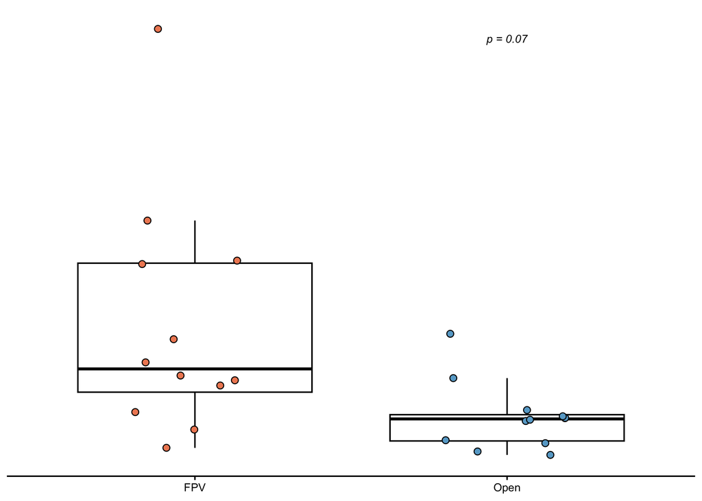

```r
# 3. box plot
methanotroph_bottom_box <- methanotroph_bottom_data %>%
  ggplot(aes(x = solar_progress, y = total_abundance, color = solar_progress)) +
  geom_boxplot(outlier.shape = NA, color = "black") +
  geom_jitter(aes(color = solar_progress, fill = solar_progress), width = 0.2, size = 2, shape = 21) +
  scale_fill_manual(values = solar_colors) +
  scale_color_manual(values = c("black", "black"))+
  scale_y_continuous(
    breaks = c(0, 5e5, 1e6),
    labels = c("0", "500K", "1M"))+
  # scale_y_continuous(
  #   breaks = c(0, 2.5e5, 7.5e5, 1.25e6),
  #   labels = c("0","250K", "750K", "1.25M"))+
    #labels = label_number(scale_cut = cut_short_scale())) +
  theme_classic()+
  theme(axis.text.x = element_text(size = 8,colour = "black"),
        axis.title.x = element_blank(),
        axis.title.y = element_blank(),
        axis.line.y = element_blank(),
        axis.text.y = element_blank(),
        axis.ticks.y = element_blank(),
        legend.position = "none") +#+
  # stat_compare_means(method = "wilcox.test",
  #                    #comparisons = list(c("FPV", "Open")),
  #                    label = "p.format",
  #                    size = 3,
  #                    label.y.npc = 0.9,
  #                    fontface = "italic")
  #                    #label.y = c(8000, 100000, 500000, 400000, 400000), # get pvalue
 annotate("text", x = 2, y = 1e6, label = "p = 0.07", size = 2.822,  fontface = "italic") # add p value
methanotroph_bottom_box
```

```r
#### Sediment Summary Stats
sed_ch4_cyclers_df %>%
  group_by(solar_progress, CH4_Cycler) %>%
  dplyr::summarize(sd_meth = sd(rel_abundance*100),
                   mean_meth = mean(rel_abundance*100))
```

```
## # A tibble: 4 × 4
## # Groups:   solar_progress [2]
##   solar_progress CH4_Cycler   sd_meth mean_meth
##   <fct>          <chr>          <dbl>     <dbl>
## 1 FPV            Methanogen      3.99     14.6
## 2 FPV            Methanotroph    1.34      3.85
## 3 Open           Methanogen      3.51     15.5
## 4 Open           Methanotroph    1.41      4.44
```

```r
##### sediment methanogen #####
# calculate stats
# 1a. calcualte abundance
methanogen_sed_sum <- sed_ch4_cyclers_df %>%
  dplyr::filter(CH4_Cycler == "Methanogen") %>%
 # group_by(solar_progress) %>% # when this is commented out then roughly 20% of community is methanogens
 # group_by(solar_progress) %>%  # when this is run then fpv has 18.9% methanogens and controls have more with 20.5%
  group_by(solar_progress, JDate) %>%
  dplyr::summarize(sd_meth = sd(rel_abundance),
                   mean_meth = mean(rel_abundance))
methanogen_sed_sum
```

```
## # A tibble: 8 × 4
## # Groups:   solar_progress [2]
##   solar_progress JDate sd_meth mean_meth
##   <fct>          <dbl>   <dbl>     <dbl>
## 1 FPV              172  0.0287     0.153
## 2 FPV              193  0.0334     0.180
## 3 FPV              234  0.0240     0.147
## 4 FPV              255  0.0364     0.105
## 5 Open             172  0.0184     0.162
## 6 Open             193  0.0149     0.157
## 7 Open             234  0.0356     0.165
## 8 Open             255  0.0633     0.134
```

```r
max(methanogen_sed_sum$mean_meth)
```

```
## [1] 0.1803245
```

```r
min(methanogen_sed_sum$mean_meth)
```

```
## [1] 0.1046341
```

```r
# 1b. linear mixed model
methanogen_sed_data <- sed_ch4_cyclers_df %>%
  dplyr::filter(CH4_Cycler == "Methanogen")
methanogen_sed_data$Pond <- as.factor(methanogen_sed_data$Pond)

sed_methanogen_model <- lmer(rel_abundance ~ solar_progress + JDate + (1|Pond), data = methanogen_sed_data)
summary(sed_methanogen_model) # 0.7598
```

```
## Linear mixed model fit by REML. t-tests use Satterthwaite's method ['lmerModLmerTest']
## Formula: rel_abundance ~ solar_progress + JDate + (1 | Pond)
##    Data: methanogen_sed_data
##
## REML criterion at convergence: -64.9
##
## Scaled residuals:
##     Min      1Q  Median      3Q     Max
## -1.9877 -0.4323 -0.1066  0.7566  1.4540
##
## Random effects:
##  Groups   Name        Variance  Std.Dev.
##  Pond     (Intercept) 0.0005099 0.02258
##  Residual             0.0008464 0.02909
## Number of obs: 23, groups:  Pond, 6
##
## Fixed effects:
##                      Estimate Std. Error         df t value Pr(>|t|)
## (Intercept)         0.2378548  0.0418243 19.5467203   5.687 1.58e-05 ***
## solar_progressOpen  0.0072475  0.0221027  3.8979966   0.328   0.7598
## JDate              -0.0004243  0.0001833 15.9481818  -2.314   0.0343 *
## ---
## Signif. codes:  0 '***' 0.001 '**' 0.01 '*' 0.05 '.' 0.1 ' ' 1
##
## Correlation of Fixed Effects:
##             (Intr) slr_pO
## slr_prgrssO -0.252
## JDate       -0.926 -0.018
```

```r
emmeans::emmeans(sed_methanogen_model, pairwise ~ solar_progress) # 0.7596
```

```
## $emmeans
##  solar_progress emmean     SE   df lower.CL upper.CL
##  FPV             0.148 0.0158 4.11    0.104    0.191
##  Open            0.155 0.0155 3.88    0.111    0.198
##
## Degrees-of-freedom method: kenward-roger
## Confidence level used: 0.95
##
## $contrasts
##  contrast   estimate     SE   df t.ratio p.value
##  FPV - Open -0.00725 0.0221 3.99  -0.328  0.7596
##
## Degrees-of-freedom method: kenward-roger
```

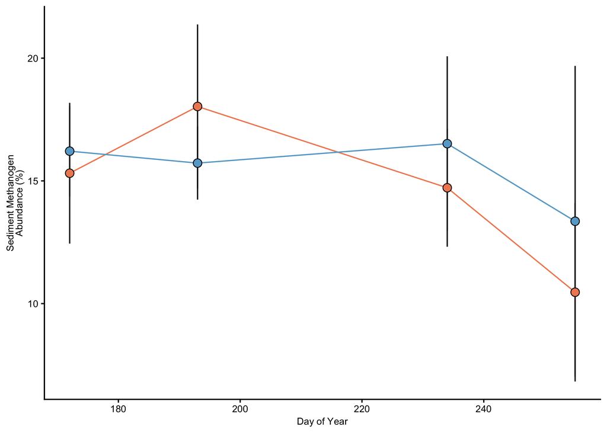

```r
# plot sediment methanogens
methanogen_sed <- methanogen_sed_sum %>%
  ggplot(aes(x = JDate, y = mean_meth*100, fill = solar_progress, color = solar_progress)) +
  geom_line()+
  geom_point()+
  theme_classic()+
  geom_errorbar(aes(x = JDate, ymin = mean_meth*100 - sd_meth*100,
                    ymax = mean_meth*100 + sd_meth*100), width = 0, color = "black")+
  geom_point(size = 3, shape = 16)+
  geom_point(size = 3, shape = 1, color = "black")+
  scale_fill_manual(values = solar_colors)+
  scale_color_manual(values = solar_colors)+
  scale_y_continuous(
    breaks = scales::pretty_breaks(n = 3),
   labels = label_number(scale_cut = cut_short_scale())) +
  # scale_y_continuous(
  #   limits = c(.1*100, .22*100),
  #   breaks = c(0.1*100, .15*100, .20*100))+
 #labels = label_number(scale_cut = cut_short_scale())) +
  labs(y= "Sediment Methanogen<br> Abundance (%)", x = "Day of Year")+
  theme(axis.text.x =  element_text(size = 8,colour = "black"),
         axis.text.y =  element_text(size = 8,colour = "black"),
         axis.title.x = element_text(size = 8,colour = "black"),
        axis.title.y = element_markdown(size = 8))+
  theme(legend.position = "none")
methanogen_sed
```

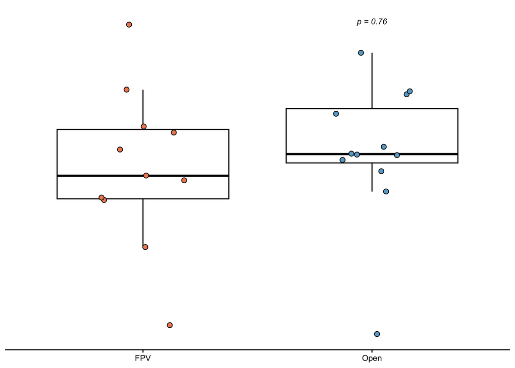

```r
# 3. box plot
methanogen_sed_box <- methanogen_sed_data %>%
  ggplot(aes(x = solar_progress, y = rel_abundance*100, color = solar_progress)) +
  geom_boxplot(outlier.shape = NA, color = "black") +
  geom_jitter(aes(color = solar_progress, fill = solar_progress), width = 0.2, size = 2, shape = 21) +
  scale_fill_manual(values = solar_colors)+
  scale_color_manual(values = c("black", "black"))+
  scale_y_continuous(
    breaks = scales::pretty_breaks(n = 3),
    labels = label_number(scale_cut = cut_short_scale())) +
  # scale_y_continuous(
  #   limits = c(.08*100, .3*100),
  #   breaks = c(0.1*100, .2*100, .30*100))+
  theme_classic()+
  theme(axis.text.x = element_text(size = 8,colour = "black"),
        axis.title.x = element_blank(),
        axis.title.y = element_blank(),
        axis.line.y = element_blank(),
        axis.text.y = element_blank(),
        axis.ticks.y = element_blank(),
        legend.position = "none") +
 annotate("text", x = 2, y = 22, label = "p = 0.76", size = 2.822,  fontface = "italic")
methanogen_sed_box
```

```r
##### sediment methanotrophs #####
#1. calculate stats
#1a. calclate abundance
methanotroph_sed_sum <- sed_ch4_cyclers_df %>%
  dplyr::filter(CH4_Cycler == "Methanotroph") %>%
  # group_by(solar_progress) %>% # when this is commented out then roughly 6% of community is methanotrophs
  #group_by(solar_progress) %>%  # when this is run then fpv has 6% methanotrophs and controls have more with 7% methanotrophs
  group_by(solar_progress, JDate) %>%
  dplyr::summarize(sd_meth = sd(rel_abundance),
                   mean_meth = mean(rel_abundance))
methanotroph_sed_sum
```

```
## # A tibble: 8 × 4
## # Groups:   solar_progress [2]
##   solar_progress JDate sd_meth mean_meth
##   <fct>          <dbl>   <dbl>     <dbl>
## 1 FPV              172 0.0177     0.0493
## 2 FPV              193 0.00849    0.0417
## 3 FPV              234 0.00177    0.0347
## 4 FPV              255 0.0108     0.0270
## 5 Open             172 0.00341    0.0431
## 6 Open             193 0.00603    0.0645
## 7 Open             234 0.00375    0.0373
## 8 Open             255 0.0117     0.0326
```

```r
max(methanotroph_sed_sum$mean_meth)
```

```
## [1] 0.06449011
```

```r
min(methanotroph_sed_sum$mean_meth)
```

```
## [1] 0.02704562
```

```r
#1b linear mixed model
methanotroph_sed_data <- sed_ch4_cyclers_df %>%
  dplyr::filter(CH4_Cycler == "Methanotroph")
methanotroph_sed_data$Pond <- as.factor(methanotroph_sed_data$Pond)

sed_methanotroph_model <- lmerTest::lmer(rel_abundance ~ solar_progress + JDate + (1|Pond), data = methanotroph_sed_data)
summary(sed_methanotroph_model) # 0.18701
```

```
## Linear mixed model fit by REML. t-tests use Satterthwaite's method ['lmerModLmerTest']
## Formula: rel_abundance ~ solar_progress + JDate + (1 | Pond)
##    Data: methanotroph_sed_data
##
## REML criterion at convergence: -107.9
##
## Scaled residuals:
##      Min       1Q   Median       3Q      Max
## -1.30338 -0.72030  0.03134  0.73645  1.96982
##
## Random effects:
##  Groups   Name        Variance  Std.Dev.
##  Pond     (Intercept) 0.0000000 0.00000
##  Residual             0.0001257 0.01121
## Number of obs: 23, groups:  Pond, 6
##
## Fixed effects:
##                      Estimate Std. Error         df t value Pr(>|t|)
## (Intercept)         8.971e-02  1.531e-02  2.000e+01   5.860 9.87e-06 ***
## solar_progressOpen  6.337e-03  4.682e-03  2.000e+01   1.354  0.19098
## JDate              -2.419e-04  7.055e-05  2.000e+01  -3.429  0.00266 **
## ---
## Signif. codes:  0 '***' 0.001 '**' 0.01 '*' 0.05 '.' 0.1 ' ' 1
##
## Correlation of Fixed Effects:
##             (Intr) slr_pO
## slr_prgrssO -0.132
## JDate       -0.975 -0.028
## optimizer (nloptwrap) convergence code: 0 (OK)
## boundary (singular) fit: see help('isSingular')
```

```r
emmeans::lsmeans(sed_methanotroph_model, pairwise ~ solar_progress) #0.2464
```

```
## $lsmeans
##  solar_progress lsmean      SE   df lower.CL upper.CL
##  FPV            0.0383 0.00341 4.22   0.0290   0.0475
##  Open           0.0446 0.00324 3.67   0.0353   0.0539
##
## Degrees-of-freedom method: kenward-roger
## Confidence level used: 0.95
##
## $contrasts
##  contrast   estimate     SE   df t.ratio p.value
##  FPV - Open -0.00634 0.0047 3.94  -1.347  0.2500
##
## Degrees-of-freedom method: kenward-roger
```

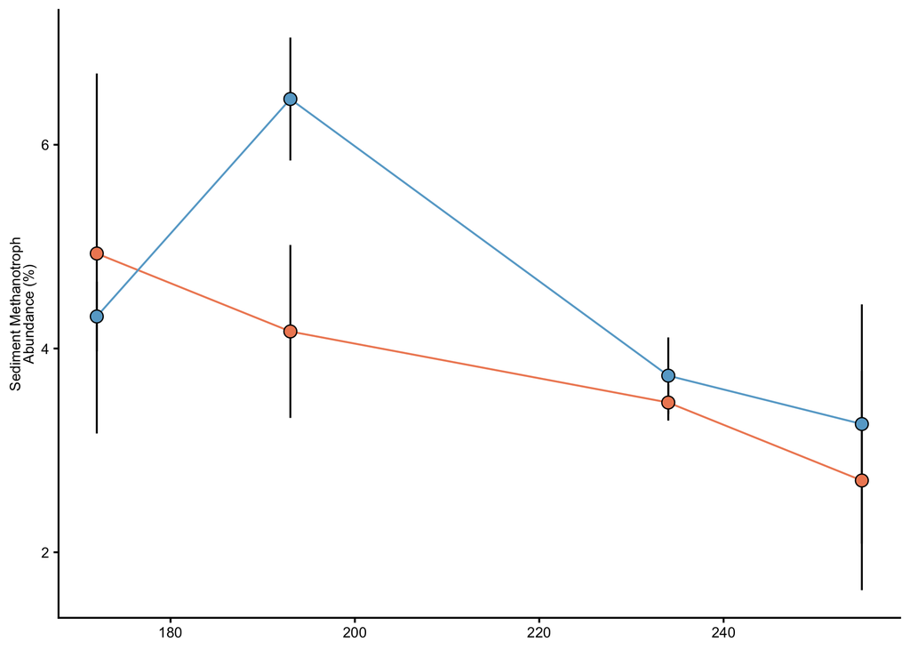

```r
# 2. plot sed methanotrophs overtime
methanotroph_sed <- methanotroph_sed_sum %>%
  ggplot(aes(x = JDate, y = mean_meth*100, fill = solar_progress, color = solar_progress)) +
  geom_line()+
  geom_point()+
  theme_classic()+
  geom_errorbar(aes(x = JDate, ymin = mean_meth*100 - sd_meth*100,
                    ymax = mean_meth*100 + sd_meth*100), width = 0, color = "black")+
  geom_point(size = 3, shape = 16)+
  geom_point(size = 3, shape = 1, color = "black") +
  labs(y= "Sediment Methanotroph<br>Abundance (%)", x = "Day of Year")+
  theme(axis.text.x =  element_text(size = 8,colour = "black"),
         axis.text.y =  element_text(size = 8,colour = "black"),
         axis.title.x = element_blank(),
        axis.title.y = element_markdown(size = 8))+
  scale_fill_manual(values = solar_colors)+
  scale_color_manual(values = solar_colors)+
  scale_y_continuous(
    breaks = scales::pretty_breaks(n = 3),
    labels = label_number(scale_cut = cut_short_scale())) +
  theme(legend.position = "none")
methanotroph_sed
```

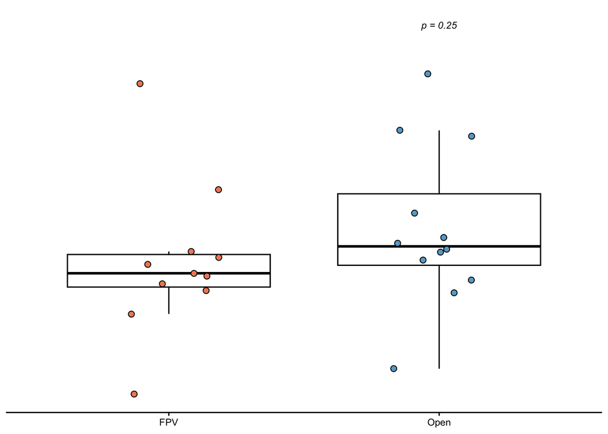

```r
# box plot
methanotroph_sed_box <- methanotroph_sed_data %>%
  ggplot(aes(x = solar_progress, y = rel_abundance*100, color = solar_progress)) +
  geom_boxplot(outlier.shape = NA, color = "black") +
  geom_jitter(aes(color = solar_progress, fill = solar_progress), width = 0.2, size = 2, shape = 21) +
  scale_fill_manual(values = solar_colors)+
  scale_color_manual(values = c("black", "black")) +
  scale_y_continuous(
    breaks = scales::pretty_breaks(n = 3),
    labels = label_number(scale_cut = cut_short_scale())) +
  theme_classic()+
  theme(axis.text.x = element_text(size = 8, colour = "black"),
        axis.title.x = element_blank(),
        axis.title.y = element_blank(),
        axis.line.y = element_blank(),
        axis.text.y = element_blank(),
        axis.ticks.y = element_blank(),
        legend.position = "none") +#+
  # stat_compare_means(method = "wilcox.test",
  #                    #comparisons = list(c("FPV", "Open")),
  #                    label = "p.format",
  #                    size = 3,
  #                    label.y.npc = 0.9,
  #                    fontface = "italic")
  #                    #label.y = c(8000, 100000, 500000, 400000, 400000), # get pvalue
 annotate("text", x = 2, y = 8, label = "p = 0.25", size = 2.822,  fontface = "italic") # add p value
methanotroph_sed_box
```

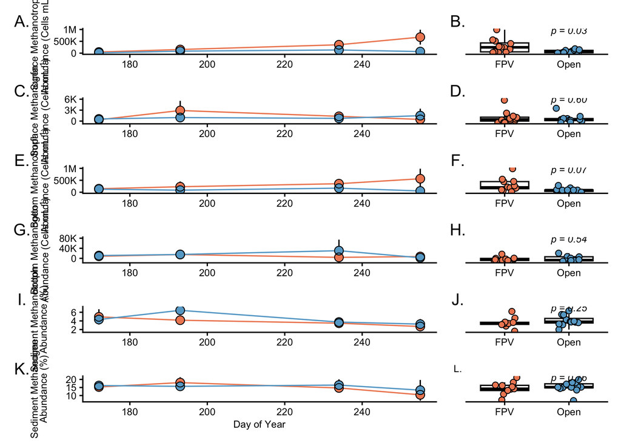

```r
## plot all together
fig2 <- methanotroph_surface + methanotroph_surface_box + methanogen_surface + methanogen_surface_box +
  methanotroph_bottom + methanotroph_bottom_box + methanogen_bottom + methanogen_bottom_box +
  methanotroph_sed + methanotroph_sed_box + methanogen_sed + methanogen_sed_box +
  plot_layout(nrow = 6, ncol = 2,
              widths = c(10, 4)) +
  plot_annotation(tag_levels = "A", tag_suffix = '.') +
  theme(
    plot.tag = element_text(size = 8))
fig2
```

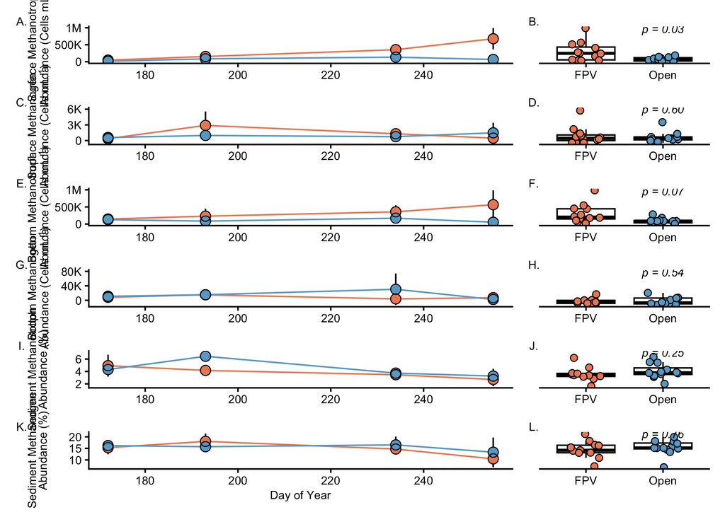

```r
fig2 <- methanotroph_surface + methanotroph_surface_box +
  methanogen_surface + methanogen_surface_box +
  methanotroph_bottom + methanotroph_bottom_box +
  methanogen_bottom + methanogen_bottom_box +
  methanotroph_sed + methanotroph_sed_box +
  methanogen_sed + methanogen_sed_box +
  plot_layout(nrow = 6, ncol = 2, widths = c(10, 4)) +
  plot_annotation(tag_levels = "A",
                  tag_suffix = ".") &
  theme(
    plot.tag = element_text(size = 8)); fig2
```

```r
#export the figure
ggsave(fig2, width = 6.5, height = 8.5, units = "in", filename = "figures/Fig_2/fig2.png") # could only save at height 8.5, orignally h = 8
```

We have created main text `fig2` which shows the abundance of water column (absolute abundance) and sediment (relative abundance) methanotrophs and methanogens over time between FPV and Open ponds.

Each row corresponds to depth (surface water, bottom water, or sediments) and methane cycler (methanotroph or methanogen). The left panel demonstrates the temporal relationships while the right panel is a box plot comparison with linear mixed effects statistical analysis between FPV and Open ponds.

# Figure 3

Now plot beta diversity with Bray-Curtis dissimilarity matrix for all methane cyclers (methanogens and methanotrophs) in water column and sediments

### Fig 3A: Water PCoA

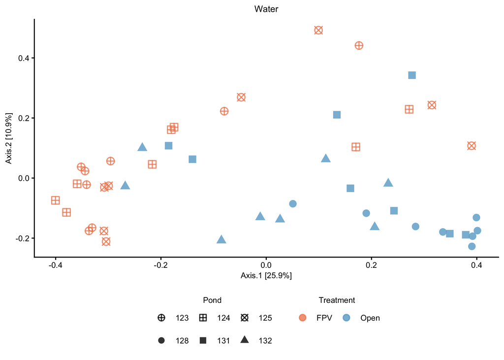

```r
# water methane cyclers

# Calculate Bray-Curtis Dissimilarity
water_BC_pcoa <-
  ordinate(
    physeq = water_ch4_cyclers_physeq,
    method = "PCoA",
    distance = "bray",
    binary = FALSE
  )



#### Grab the data for the plot
water_all_ord_df <-
  plot_ordination(
  physeq = water_ch4_cyclers_physeq,
  ordination = water_BC_pcoa,
  color = "solar_progress",
  shape = "Pond",
  justDF = TRUE)

# now lets mutate the columns
water_all_ord_df <- water_all_ord_df %>%
dplyr::mutate(
    solar_progress = recode(solar_progress, "FPV" = "FPV", "No FPV" = "Open"), # solar progress
    Depth_Class = recode(Depth_Class,  # depth class
      "S" = "Surface Water",
      "B" = "Bottom Water"))


### Now, plot Figure 3A: WATER
fig3a_water_pcoa <-
  ggplot(data = water_all_ord_df,
       aes(x = Axis.1,
           y = Axis.2,
           color = solar_progress,
           shape = Pond)) +
  geom_point(size = 3, alpha = 0.8, stroke = 0.8) +
  scale_shape_manual(values = pond_shapes) +
  scale_color_manual(values = solar_colors) +
  labs(color = "Treatment",
       shape = "Pond",
       x = "Axis.1 [25.9%]",
       y = "Axis.2 [10.9%]",
       title = expression("Water")) +  # CH"[4]*" Cyclers
  guides(
    color = guide_legend(
      title.position = "top",
      title.hjust = 0.5,
      override.aes = list(size = 2.5)),
    shape = guide_legend(
      nrow = 2,
      byrow = TRUE,
      title.position = "top",
      title.hjust = 0.5,
      override.aes = list(size = 2.5))
  ) +
  theme_classic() +
  theme(legend.position = "bottom",
        #legend.spacing = unit(0, "cm"),
        legend.box.background = element_blank(),
        legend.title = element_text(size = 8),
        legend.text = element_text(size = 8),
        plot.title = element_text(hjust = 0.5, size = 9, colour = "black"),
        axis.text.x = element_text(size = 8, colour = "black"),
        axis.text.y = element_text(size = 8, colour = "black"),
        axis.title.x = element_text(size = 8, colour = "black"),
        axis.title.y = element_text(size = 8, colour = "black"))

# Show the plot
fig3a_water_pcoa
```

```r
### Sophia's plot - for axes labels
# PCoA of water samples color by treatment shape by pond
# s1a_water_pcoa <- plot_ordination(
#   physeq = water_physeq_24,
#   ordination = water_BC_pcoa,
#   color = "solar_progress",
#   shape = "Pond",
#   title = "Water Column Methane Cyclers") +
#   geom_point(size = 5, alpha = 0.5,
#              aes(fill = solar_progress, color = solar_progress, shape = Pond)) +
#   scale_fill_manual(values = solar_colors) +
#   scale_color_manual(values = solar_colors) +
#   scale_shape_manual(values = pond_shapes) +
#   guides(color = guide_legend(nrow = 1,
#                               title = NULL,
#                               override.aes = list(size = 2.7)),
#          fill = "none",
#          shape = guide_legend(nrow = 2,
#                               byrow = TRUE,
#                               title = NULL,
#                               override.aes = list(size = 2.7))) +
#   theme_classic() +
#   theme(
#     legend.position = c(0.01, 0.01),  # inside bottom-left
#     legend.justification = c(.01, .01),
#     legend.spacing = unit(0.01, "cm"),
#     legend.spacing.x = unit(0.1, "cm"),
#     legend.background = element_rect(color = NA, fill = NA),
#     legend.key.width = unit(0.2, "cm"),
#     legend.key.height = unit(0.4, "cm"),
#     legend.text = element_text(size = 6),
#     legend.box.just = "center",
#     legend.box.background = element_rect(size = 0.2, linetype = "solid", color = "black"),
#     legend.margin = margin(1, 2, 1, 1))

# Plot it
# s1a_water_pcoa
```

### Fig 3B: Sediment PCoA

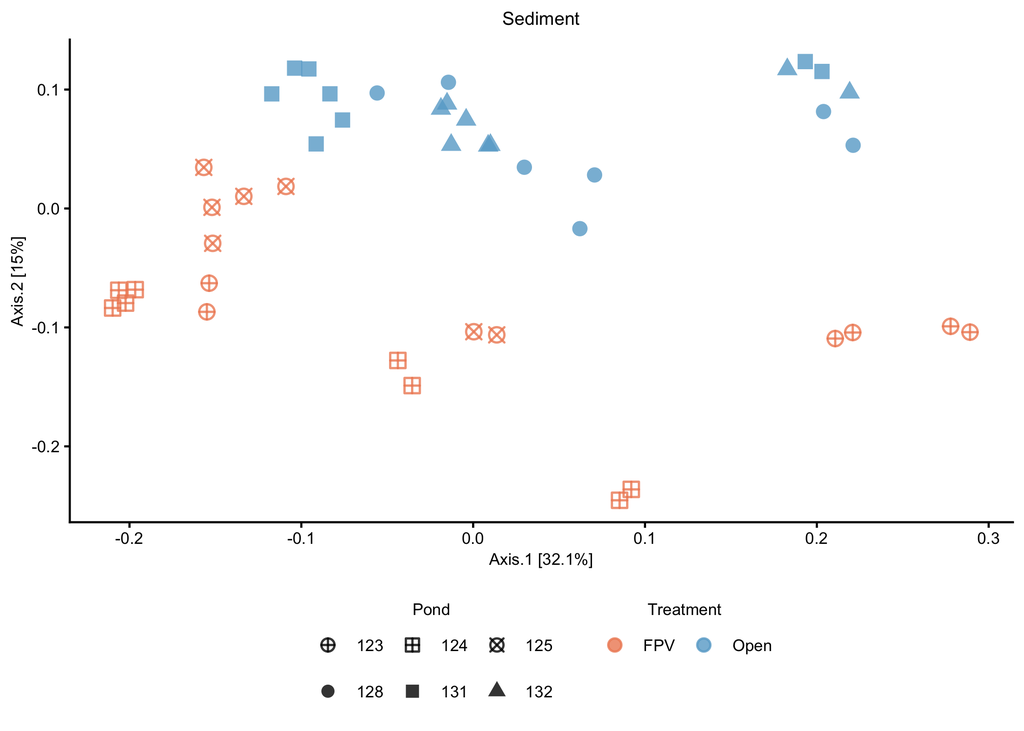

```r
# Calculate Bray-Curtis Dissimilarity
scaled_sed_BC_pcoa <-
  ordinate(
    physeq = sed_ch4_cyclers_physeq,
    method = "PCoA",
    distance = "bray",
    binary = FALSE
  )


#### Grab the data for the plot
sed_all_ord_df <-
  plot_ordination(
  physeq = sed_ch4_cyclers_physeq,
  ordination = scaled_sed_BC_pcoa,
  color = "solar_progress",
  shape = "Pond",
  justDF = TRUE)

# update metadata for plotting
sed_all_ord_df <- sed_all_ord_df %>%
dplyr::mutate(
    solar_progress = recode(solar_progress, "FPV" = "FPV", "No FPV" = "Open"), # solar progress
    Depth_Class = recode(Depth_Class,  # depth class
      "S" = "Surface Water",
      "B" = "Bottom Water"))

# Now plot it!
fig3b_sed_pcoa <-
  ggplot(data = sed_all_ord_df,
       aes(x = Axis.1,
           y = Axis.2,
           color = solar_progress,
           shape = Pond)) +
  geom_point(size = 3, alpha = 0.8, stroke = 0.8) +
  scale_shape_manual(values = pond_shapes) +
  scale_color_manual(values = solar_colors) +
  labs(color = "Treatment",
       shape = "Pond",
       x = "Axis.1 [32.1%]",
       y = "Axis.2 [15%]",
       title = expression("Sediment")) + #  CH"[4]*" Cyclers
  guides(
    color = guide_legend(
      title.position = "top",
      title.hjust = 0.5,
      override.aes = list(size = 2.5)),
    shape = guide_legend(
      nrow = 2,
      byrow = TRUE,
      title.position = "top",
      title.hjust = 0.5,
      override.aes = list(size = 2.5))
  ) +
  theme_classic() +
  theme(legend.position = "bottom",
        #legend.spacing = unit(0, "cm"),
        legend.box.background = element_blank(),
        legend.title = element_text(size = 8),
        legend.text = element_text(size = 8),
        plot.title = element_text(hjust = 0.5, size = 9, colour = "black"),
        axis.text.x = element_text(size = 8, colour = "black"),
        axis.text.y = element_text(size = 8, colour = "black"),
        axis.title.x = element_text(size = 8, colour = "black"),
        axis.title.y = element_text(size = 8, colour = "black"))

# Show the plot
fig3b_sed_pcoa
```

```r
# Sophia's plot
# PCoA of sediments color by treatment shaped by pond
# s1b_sed_pcoa <-
#   plot_ordination(
#   physeq = sed_ch4_cyclers_physeq,
#   ordination = scaled_sed_BC_pcoa,
#   color = "solar_progress",
#   shape = "Pond",
#   title = "Sediment Methane Cyclers") +
#   geom_point(size = 5, alpha = 0.5,
#              aes(color = solar_progress, fill = solar_progress, shape = Pond)) +
#   scale_color_manual(values = solar_colors) +
#   scale_fill_manual(values = solar_colors) +
#   scale_shape_manual(values = pond_shapes) +
#   guides(color = "none",
#          fill = "none",
#          shape = "none") +
#   theme_classic()
#   # theme(
#   # legend.position = c(0.82, 0.01),  # inside bottom-left
#   # legend.justification = c(0, 0),  # anchor the legend's top-left corner there
#   # legend.spacing = unit(0.1, "cm"),
#   # legend.background = element_rect(color = NA, fill = NA),
#   # legend.box.background = element_rect(size = 0.1, linetype = "solid", color = "black"),
#   # legend.text = element_text(size = 6),
#   # legend.margin = margin(2, 2, 2, 2))
# s1b_sed_pcoa

# ggsave(s1b_sed_pcoa, width = 8, height = 7, units = "in",
#         filename = "figures/s1b/s1b_sed_pcoa.png")
```

### Save Figure 3

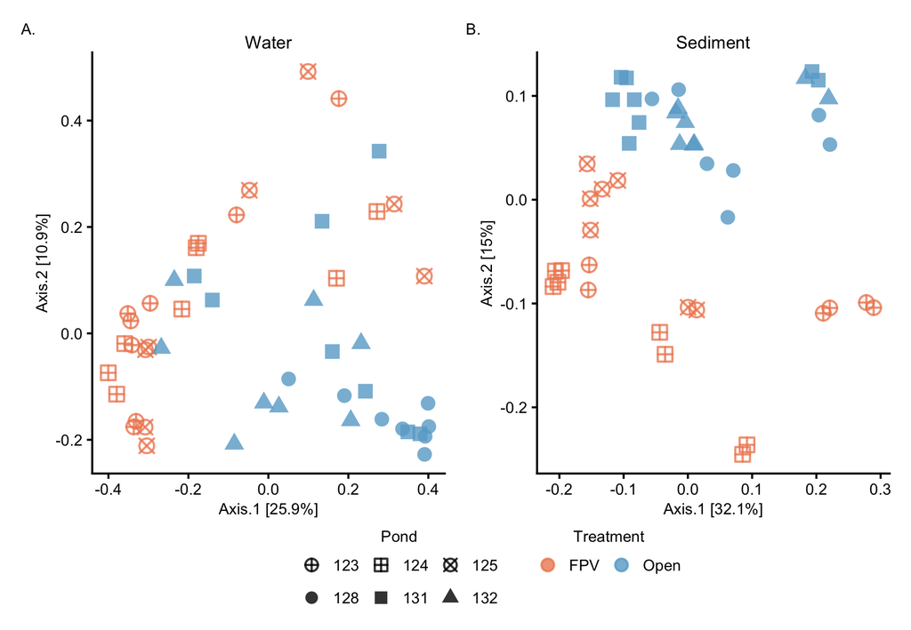

```r
library(patchwork)

### Final Plot for Submission
plot_fig3 <-
  fig3a_water_pcoa + theme(plot.title = element_text(margin = margin(b = 0))) +
  fig3b_sed_pcoa + theme(plot.title = element_text(margin = margin(b = 0))) +
  plot_annotation(tag_levels = "A", tag_suffix = ".") +
    plot_layout(guides = "collect") &
  theme(
    plot.tag = element_text(size = 8, colour = "black"),
    legend.position = "bottom",
    # legend.title = element_text(size = 9),
    # legend.text = element_text(size = 8),
    legend.key.size = unit(0.4, "cm"),
    legend.spacing.x = unit(0.7, "cm"),
    legend.margin = margin(t = -5, unit = "pt")
  )
plot_fig3
```

```r
# png
ggsave(plot_fig3, width = 6, height = 3.5, dpi = 300,
        filename = "figures/Fig_3.png")

# save as .jpeg
ggsave(plot_fig3, width = 6, height = 3.5, dpi = 300,
        filename = "figures/Fig_3.jpeg")
```

## Fig 3: PERMANOVA

PERMANOVA (Permutational Multivariate Analysis of Variance) is a non-parametric, permutation-based test used to compare groups of objects based on a distance matrix. The goal is to test the null hypothesis that the centroids and dispersion of groups are equivalent in the space defined by the dissimilarity measure.

```r
#### WATER COLUMN: All methane cyclers
# calculate Bray-Curtis PERMANOVA using phyloseq distance
water_bray <- phyloseq::distance(water_ch4_cyclers_physeq, method = "bray", binary = FALSE)

# pull out metadata
water_metadata <- water_ch4_cyclers_physeq %>%
  sample_data() %>%
  data.frame()


#### SEDIMENT: All methane cyclers
# calculate Bray-Curtis PERMANOVA using phyloseq distance
sed_bray <- phyloseq::distance(sed_ch4_cyclers_physeq, method = "bray", binary = FALSE)

# pull out metadata
sed_metadata <- sed_ch4_cyclers_physeq %>%
  sample_data() %>%
  data.frame()
```

### Water

Here we are performing a PERMANOVA on the water column methane cyclers throughout the entire sampling season.

```r
# Permutational Multivariate Analysis of Variance Using Distance Matrices
# aka PERMANOVA using the adonis2 function from vegan

#1. Test the individual terms for significance
# Testing if the centroids of solar progress are different: significant p = 0.001 ***
adonis2(water_bray ~ solar_progress, data = water_metadata, by = "terms")
```

```
## Permutation test for adonis under reduced model
## Terms added sequentially (first to last)
## Permutation: free
## Number of permutations: 999
##
## adonis2(formula = water_bray ~ solar_progress, data = water_metadata, by = "terms")
##                Df SumOfSqs      R2      F Pr(>F)
## solar_progress  1   1.6055 0.11599 6.0359  0.001 ***
## Residual       46  12.2357 0.88401
## Total          47  13.8412 1.00000
## ---
## Signif. codes:  0 '***' 0.001 '**' 0.01 '*' 0.05 '.' 0.1 ' ' 1
```

```r
# Now testing to see if centroids of depth_class are different: not significant p = 0.19
adonis2(water_bray ~ Depth_Class, data = water_metadata, by = "terms")
```

```
## Permutation test for adonis under reduced model
## Terms added sequentially (first to last)
## Permutation: free
## Number of permutations: 999
##
## adonis2(formula = water_bray ~ Depth_Class, data = water_metadata, by = "terms")
##             Df SumOfSqs      R2      F Pr(>F)
## Depth_Class  1   0.3712 0.02682 1.2676  0.199
## Residual    46  13.4700 0.97318
## Total       47  13.8412 1.00000
```

```r
# Does pond matter? significant p = 0.001 ***
adonis2(water_bray ~ Pond, data = water_metadata, by = "terms")
```

```
## Permutation test for adonis under reduced model
## Terms added sequentially (first to last)
## Permutation: free
## Number of permutations: 999
##
## adonis2(formula = water_bray ~ Pond, data = water_metadata, by = "terms")
##          Df SumOfSqs      R2      F Pr(>F)
## Pond      5   3.8474 0.27797 3.2338  0.001 ***
## Residual 42   9.9938 0.72203
## Total    47  13.8412 1.00000
## ---
## Signif. codes:  0 '***' 0.001 '**' 0.01 '*' 0.05 '.' 0.1 ' ' 1
```

```r
# Does date matter? significant p = 0.001 ***
adonis2(water_bray ~ JDate, data = water_metadata, by = "terms")
```

```
## Permutation test for adonis under reduced model
## Terms added sequentially (first to last)
## Permutation: free
## Number of permutations: 999
##
## adonis2(formula = water_bray ~ JDate, data = water_metadata, by = "terms")
##          Df SumOfSqs    R2      F Pr(>F)
## JDate     1   1.0658 0.077 3.8376  0.001 ***
## Residual 46  12.7754 0.923
## Total    47  13.8412 1.000
## ---
## Signif. codes:  0 '***' 0.001 '**' 0.01 '*' 0.05 '.' 0.1 ' ' 1
```

```r
#2. Test the terms together
# Now lets see the effect of each pond by date_collected and solar progress
water_permanova <- adonis2(water_bray ~ solar_progress * Pond * JDate * Depth_Class, data = water_metadata, by = "terms"); water_permanova
```

```
## Permutation test for adonis under reduced model
## Terms added sequentially (first to last)
## Permutation: free
## Number of permutations: 999
##
## adonis2(formula = water_bray ~ solar_progress * Pond * JDate * Depth_Class, data = water_metadata, by = "terms")
##                                  Df SumOfSqs      R2      F Pr(>F)
## solar_progress                    1   1.6055 0.11599 8.1774  0.001 ***
## Pond                              4   2.2419 0.16197 2.8547  0.001 ***
## JDate                             1   1.0658 0.07700 5.4285  0.001 ***
## Depth_Class                       1   0.3712 0.02682 1.8906  0.031 *
## solar_progress:JDate              1   0.8822 0.06374 4.4933  0.001 ***
## Pond:JDate                        4   1.1885 0.08586 1.5133  0.037 *
## solar_progress:Depth_Class        1   0.1754 0.01267 0.8934  0.517
## Pond:Depth_Class                  4   0.5270 0.03807 0.6710  0.952
## JDate:Depth_Class                 1   0.4191 0.03028 2.1348  0.035 *
## solar_progress:JDate:Depth_Class  1   0.1699 0.01227 0.8653  0.568
## Pond:JDate:Depth_Class            4   0.4827 0.03487 0.6146  0.985
## Residual                         24   4.7120 0.34044
## Total                            47  13.8412 1.00000
## ---
## Signif. codes:  0 '***' 0.001 '**' 0.01 '*' 0.05 '.' 0.1 ' ' 1
```

With our PERMANOVA we find that treatment (solar_progress), day of year sampled (JDate - Julian date), and Pond is significant but depth class alone is not.

### Sediments

Here we are performing a PERMANOVA on the sediment methane cyclers throughout the entire sampling season

```r
# Permutational Multivariate Analysis of Variance Using Distance Matrices
# aka PERMANOVA using the adonis2 function from vegan

#1. Test the individual terms for significance
# Testing if the centroids of solar progress are different: significant p = 0.001 ***
adonis2(sed_bray ~ solar_progress, data = sed_metadata, by = "terms")
```

```
## Permutation test for adonis under reduced model
## Terms added sequentially (first to last)
## Permutation: free
## Number of permutations: 999
##
## adonis2(formula = sed_bray ~ solar_progress, data = sed_metadata, by = "terms")
##                Df SumOfSqs      R2      F Pr(>F)
## solar_progress  1  0.37482 0.13285 6.4343  0.001 ***
## Residual       42  2.44660 0.86715
## Total          43  2.82142 1.00000
## ---
## Signif. codes:  0 '***' 0.001 '**' 0.01 '*' 0.05 '.' 0.1 ' ' 1
```

```r
# Does pond matter? significant p = 0.001 ***
adonis2(sed_bray ~ Pond, data = sed_metadata, by = "terms")
```

```
## Permutation test for adonis under reduced model
## Terms added sequentially (first to last)
## Permutation: free
## Number of permutations: 999
##
## adonis2(formula = sed_bray ~ Pond, data = sed_metadata, by = "terms")
##          Df SumOfSqs     R2      F Pr(>F)
## Pond      5   1.2062 0.4275 5.6751  0.001 ***
## Residual 38   1.6153 0.5725
## Total    43   2.8214 1.0000
## ---
## Signif. codes:  0 '***' 0.001 '**' 0.01 '*' 0.05 '.' 0.1 ' ' 1
```

```r
# Does date matter? significant p = 0.001 ***
adonis2(sed_bray ~ JDate, data = sed_metadata, by = "terms")
```

```
## Permutation test for adonis under reduced model
## Terms added sequentially (first to last)
## Permutation: free
## Number of permutations: 999
##
## adonis2(formula = sed_bray ~ JDate, data = sed_metadata, by = "terms")
##          Df SumOfSqs      R2      F Pr(>F)
## JDate     1  0.30672 0.10871 5.1228  0.003 **
## Residual 42  2.51470 0.89129
## Total    43  2.82142 1.00000
## ---
## Signif. codes:  0 '***' 0.001 '**' 0.01 '*' 0.05 '.' 0.1 ' ' 1
```

```r
#2. Test the terms together
# Now lets see the effect of each pond by date_collected and solar progress
sediment_permanova <- adonis2(sed_bray ~ solar_progress * Pond * JDate, data = sed_metadata, by = "terms"); sediment_permanova
```

```
## Permutation test for adonis under reduced model
## Terms added sequentially (first to last)
## Permutation: free
## Number of permutations: 999
##
## adonis2(formula = sed_bray ~ solar_progress * Pond * JDate, data = sed_metadata, by = "terms")
##                      Df SumOfSqs      R2       F Pr(>F)
## solar_progress        1  0.37482 0.13285 11.7070  0.001 ***
## Pond                  4  0.83134 0.29465  6.4916  0.001 ***
## JDate                 1  0.28948 0.10260  9.0417  0.001 ***
## solar_progress:JDate  1  0.08302 0.02942  2.5930  0.017 *
## Pond:JDate            4  0.21824 0.07735  1.7041  0.014 *
## Residual             32  1.02452 0.36312
## Total                43  2.82142 1.00000
## ---
## Signif. codes:  0 '***' 0.001 '**' 0.01 '*' 0.05 '.' 0.1 ' ' 1
```

With our PERMANOVA we find that treatment (solar_progress), day of year sampled (JDate - Julian date), and Pond is significant factors.

## Fig 3: Betadisper

We are running betadispr to test variances/dispersions

When computing PERMANOVA, we must also perform betadispr analysis when analyzing beta diversity in microbial ecology. We must do it after PERMANOVA because we need to look into the assumption of PERMANOVA which is the homogeneity of group dispersions aka variances. If this assumption is violated then the PERMANOVA results might be driven by dispersion rather than true differences in community composition.

Always run betadisper() and permutest() after PERMANOVA to test whether the groups have similar within-group variation.

It works by first taking ina. distance matrix and calculates the centroid of each group in multivariate space (note it does not test for significane). After computing within-group distances, we will run permutest() to see whether those dispersiosn differ significantly between groups using PERMANOVA

The permutest works like this: - null hypothesis (H0): all groups have equal multivariate dispersion and a compute a new F-statistic for each permutation.

The p-value is the proportion of permutations where the F is as extreme or more extreme than the observed F. The result from permutest() is a robust non-parametric p-value testing whether dispersion differs across groups. If p > 0.05 (not significant), the PERMANOVA result is reliable.

If p = 0.05 (significant), be cautious—group differences may be due to dispersion, not composition! However, not all is lost as we may expect this to be biologically true.

adonis - compares centroids to see if significant difference. betadispr - compares variance/distance from centroid

### Water

```r
# Homogeneity of Disperson test with beta dispr

## Bray-Curtis
betadispr_water_pond <- betadisper(water_bray, water_metadata$Pond)
betadispr_water_solar <- betadisper(water_bray, water_metadata$solar_progress)
betadispr_water_depth <- betadisper(water_bray, water_metadata$Depth_Class)
betadispr_water_JDate <- betadisper(water_bray, water_metadata$JDate)

# permutest() performs a non-parametric permutation test, which is robust and valid for the kind of data used in beta diversity analysis (e.g., dissimilarity matrices).
permutest(betadispr_water_pond) # not significant p = 0.256
```

```
##
## Permutation test for homogeneity of multivariate dispersions
## Permutation: free
## Number of permutations: 999
##
## Response: Distances
##           Df  Sum Sq  Mean Sq      F N.Perm Pr(>F)
## Groups     5 0.07464 0.014928 0.7228    999  0.616
## Residuals 42 0.86740 0.020653
```

```r
permutest(betadispr_water_solar) # significant p = 0.011 **
```

```
##
## Permutation test for homogeneity of multivariate dispersions
## Permutation: free
## Number of permutations: 999
##
## Response: Distances
##           Df  Sum Sq  Mean Sq      F N.Perm Pr(>F)
## Groups     1 0.10739 0.107395 7.6513    999  0.005 **
## Residuals 46 0.64566 0.014036
## ---
## Signif. codes:  0 '***' 0.001 '**' 0.01 '*' 0.05 '.' 0.1 ' ' 1
```

```r
permutest(betadispr_water_depth) # not significant p = 0.417
```

```
##
## Permutation test for homogeneity of multivariate dispersions
## Permutation: free
## Number of permutations: 999
##
## Response: Distances
##           Df  Sum Sq  Mean Sq      F N.Perm Pr(>F)
## Groups     1 0.01266 0.012658 0.9291    999  0.338
## Residuals 46 0.62670 0.013624
```

```r
permutest(betadispr_water_JDate) # significant p = 0.006 **
```

```
##
## Permutation test for homogeneity of multivariate dispersions
## Permutation: free
## Number of permutations: 999
##
## Response: Distances
##           Df  Sum Sq  Mean Sq      F N.Perm Pr(>F)
## Groups     3 0.24863 0.082875 5.6392    999  0.003 **
## Residuals 44 0.64663 0.014696
## ---
## Signif. codes:  0 '***' 0.001 '**' 0.01 '*' 0.05 '.' 0.1 ' ' 1
```

With betadispr we find the PERMANOVA results are mostly valid where pond variation is consistent. The PERMANOVA and betadispr find that depth is not significant meaning that depth doesnt structure the community. This makes sense between the ponds are so shallow so they are more likely to be similar.

But treatment and date are significant meaning the differences may be due to dispersion and not composition. This could be because of temporal reasons where communities change over time with the season.

### Sediment

```r
# Homogeneity of Disperson test with beta dispr
## Bray-Curtis
betadispr_sed_pond <- betadisper(sed_bray, sed_metadata$Pond)
betadispr_sed_solar <- betadisper(sed_bray, sed_metadata$solar_progress)
betadispr_sed_JDate <- betadisper(sed_bray, sed_metadata$JDate)

# permutest() performs a non-parametric permutation test, which is robust and valid for the kind of data used in beta diversity analysis (e.g., dissimilarity matrices).
permutest(betadispr_sed_pond) # not significant p = 0.661
```

```
##
## Permutation test for homogeneity of multivariate dispersions
## Permutation: free
## Number of permutations: 999
##
## Response: Distances
##           Df   Sum Sq   Mean Sq      F N.Perm Pr(>F)
## Groups     5 0.020225 0.0040450 0.5666    999  0.742
## Residuals 38 0.271278 0.0071389
```

```r
permutest(betadispr_sed_solar) # not significant p = 0.673
```

```
##
## Permutation test for homogeneity of multivariate dispersions
## Permutation: free
## Number of permutations: 999
##
## Response: Distances
##           Df   Sum Sq   Mean Sq      F N.Perm Pr(>F)
## Groups     1 0.005467 0.0054670 1.5541    999  0.201
## Residuals 42 0.147745 0.0035177
```

```r
permutest(betadispr_sed_JDate) # not significant p = 0.162
```

```
##
## Permutation test for homogeneity of multivariate dispersions
## Permutation: free
## Number of permutations: 999
##
## Response: Distances
##           Df   Sum Sq   Mean Sq      F N.Perm Pr(>F)
## Groups     3 0.008773 0.0029243 1.3222    999  0.273
## Residuals 40 0.088472 0.0022118
```

With betadispr we find the PERMANOVA results are are valid as pond, treatment, and date are not significant but significant in the PERMANOVA. Thus our PERMANOVA result is reliable and the differences between groups are due to location/centroids of groups rather than differences in variation within groups

# Figure 4

## ANCOMBC-II - Differential Abundance

Now we will calculate the differential abundance between our water and sediment samples. First I will try to do the original methane cyclers in water and sediments. but i may also further break it down into sediment methane cycler type.

### ASVs more Abundant in FPV

#### Water

Note as of this step the results do change in that methanobacteriales is not differentially abundant anymore and we have a reduction in asv_1479 and 976. but all asvs belong to methylococcales order

```r
# filter out for ASVs with zero variances; recommended to remove them as they are sparse and lowly abundant

# remove bad taxa
bad_taxa <- c("ASV_1071", "ASV_642", "ASV_231", "ASV_8273", "ASV_7156", "ASV_10120", "ASV_3557", "ASV_7055", "ASV_4270", "ASV_2964", "ASV_2205", "ASV_1677", "ASV_1252", "ASV_10767", "ASV_2530", "ASV_4099", "ASV_7355", "ASV_3231", "ASV_2424", "ASV_4105", "ASV_1920", "ASV_11514", "ASV_4168", "ASV_4564")

water_ch4_phy_bc <- water_ch4_cyclers_physeq %>%
  subset_taxa(., !(ASV %in% bad_taxa)) %>%
  prune_taxa(taxa_sums(.) > 0,.)


# relevel solar_progress
water_ch4_cyclers_physeq@sam_data$solar_progress <- factor(water_ch4_cyclers_physeq@sam_data$solar_progress, levels = c("No FPV", "FPV"))

# run ancombc2 for water all methane cyclers
# water_ch4_asv_output <- ancombc2(data = water_ch4_phy_bc,
#                                  tax_level = "ASV", # Test for each phylum
#                                  fix_formula = "solar_progress",
#                                  p_adj_method = "fdr",
#                                  pseudo_sens = TRUE, # Run sensitivity test to make sure taxa isn't sensitive to psuedo-count choice
#                                  prv_cut = 0.05, # Prevalence filter of 1%
#                                  group = NULL, # Use Comp_Group_Hier as groups when doing pairwise comparisons
#                                  struc_zero = FALSE, # Do not detect structural zeroes
#                                  alpha = 0.05, # Significance threshold of 0.05
#                                  n_cl = 10, # Use 10 threads
#                                  verbose = FALSE, # Don't print verbose output
#                                  s0_perc = 0.05,
#                                  global = FALSE, # Run a global test (sorta like an ANOVA to first find if a given ASV is sig diff)
#                                  pairwise = FALSE) # Run pairwise tests between groups (sorta like a post-hoc test like Tukey)


# save(water_ch4_asv_output, file = "data/03_diff_abund/water_ch4_asv_output.RData")

load("data/03_diff_abund/water_ch4_asv_output.RData")


# plot ASV differential abundance
water_ch4_fsp <-
  water_ch4_asv_output$res %>%
  select(taxon, starts_with("lfc"), starts_with("diff"), starts_with("passed_ss")) %>%
  pivot_longer(cols = !taxon, names_to = "metric", values_to = "value") %>%
  separate_wider_delim(cols = metric, delim = "_", names = c("variable", "Comparison"), too_many = "merge") %>%
  mutate(Comparison = str_remove(Comparison, "\\(Intercept\\)")) %>%
  mutate(Comparison = str_remove(Comparison, "ss_")) %>%
  pivot_wider(id_cols = c("taxon","Comparison"), names_from = variable, values_from = value) %>%
  mutate(Comparison = str_remove(Comparison, "solar_progress"),
         Comparison = str_replace(Comparison, "_solar_progrss", ";")) %>%
  separate_wider_delim(Comparison, delim = ";", names = c("Ref1", "Ref2"), too_few = "align_start") %>%
  dplyr::filter(!is.na(Ref1) & Ref1 != "") %>%
  mutate(
    Ref2 = ifelse(is.na(Ref2), "No FPV", Ref2), # relevel with basegroup which is no solar
    Comparison = paste0(Ref2, " : ", Ref1)) %>%
  dplyr::filter(diff == 1, passed == 1, abs(lfc) > 1) %>% # 1.2 is good cut off to see effect, below we get ASVs with super low cell counts
  select(ASV = taxon, Comparison, lfc, passed)

## Show the Q-Values for the results section
water_ch4_asv_output$res %>%
  dplyr::transmute(ASV   = taxon,
                   lfc   = lfc_solar_progressFPV,
                   q_value     = q_solar_progressFPV,
                   diff  = diff_solar_progressFPV,
                   passed = passed_ss_solar_progressFPV) %>%
  dplyr::filter(passed, q_value < 0.05) %>%         # core inferential filter
  dplyr::mutate(Comparison = "FPV vs Open",
                x_fold_change = exp(lfc),
                direction = ifelse(lfc > 0, "higher in FPV", "lower in FPV"),
                q_nonSci = formatC(q_value, format = "f", digits = 7)) %>%
  dplyr::select(ASV, Comparison, lfc, x_fold_change, direction, q_value, q_nonSci) %>%
  dplyr::arrange(-lfc)
```

[output not shown]

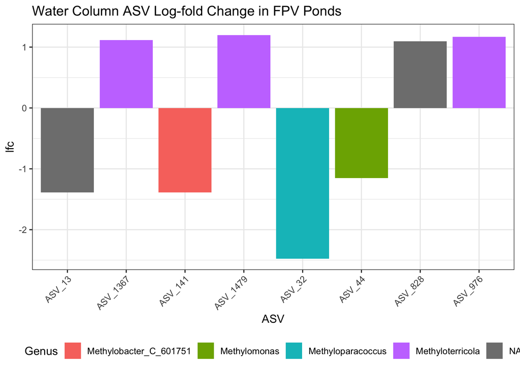

```r
# join by tax table
clean_water_ch4 <- water_ch4_fsp %>%
  left_join(., as.data.frame(water_ch4_cyclers_physeq@tax_table),
            by = "ASV")

# plot log fold changes
clean_water_ch4 %>%
  ggplot(aes(x = ASV, y = lfc, fill = Genus)) +
  geom_col() +
  #scale_fill_manual(values = phylum_colors) +
  theme_bw() +
  theme(axis.text.x = element_text(angle = 45, hjust = 1), legend.position = "bottom") +
  ggtitle("Water Column ASV Log-fold Change in FPV Ponds")
```

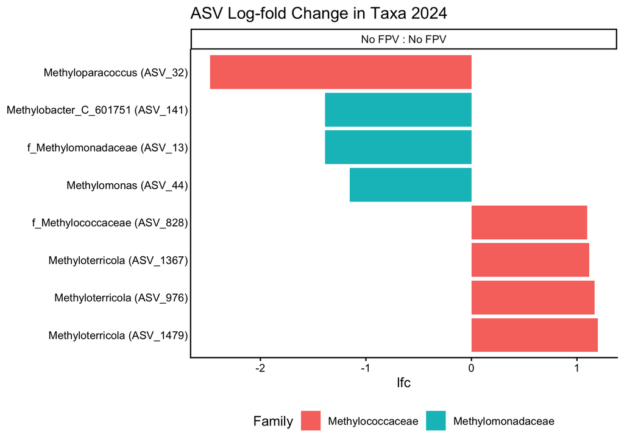

```r
# create column for nice plotting of taxnomic name and asv
clean_asv24 <- clean_water_ch4 %>%
   mutate(
    label_tax = coalesce(Genus, paste0("f_", Family), paste0("o_", Order)),
    polished_tax = paste0(label_tax, " (", ASV, ")")) %>%
  arrange(desc(lfc))

clean_asv24 <- clean_asv24 %>%
  mutate(
    polished_tax = ifelse(
      !is.na(Genus) & Genus != "",
      paste0(Genus, " (", ASV, ")"),
      ifelse(
        !is.na(Family) & Family != "",
        paste0("f_", Family, " (", ASV, ")"),
        ifelse(
          !is.na(Order) & Order != "",
          paste0("o_", Order, " (", ASV, ")"),
          ifelse(
            !is.na(Class) & Class != "",
            paste0("c_", Class, " (", ASV, ")"),
            paste0("p_", Phylum, " (", ASV, ")")
          )
        )
      )
    )
  ) %>%
  arrange(desc(lfc))

# reorder factor levels
clean_asv24$polished_tax <- factor(clean_asv24$polished_tax, levels = as.list(clean_asv24$polished_tax))


# plot log fold changes
da2 <- clean_asv24 %>%
  ggplot(aes(x = polished_tax, y = lfc, fill = Family)) +
  geom_bar(stat = "identity") +
  #scale_fill_manual(values = class_colors) +
  facet_wrap(Comparison ~.) +
  theme_classic() +
  coord_flip()+
  theme(
    legend.position = "bottom",
    axis.title.y = element_blank(),
    axis.ticks.y = element_blank()) +
  ggtitle("ASV Log-fold Change in Taxa 2024")
da2
```

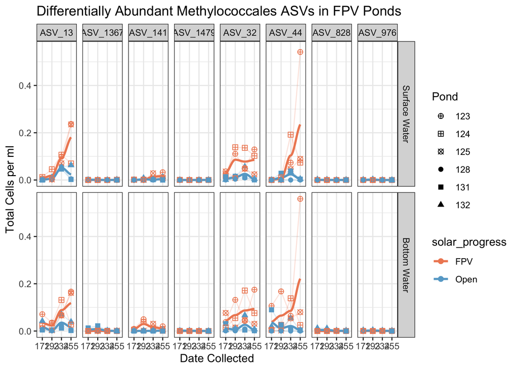

```r
# plot differentially abundant ASVs overtime

#1. tax glom at ASV level
water_ch4_asv_df_glom <- water_ch4_cyclers_physeq %>%
  tax_glom(taxrank = "ASV") %>%
  psmelt() %>%
  mutate(
    solar_progress = recode(solar_progress, "Solar" = "FPV", "No FPV" = "Open"),
    Depth_Class = case_when(
      Depth_Class == "S" ~ "Surface Water",
      Depth_Class == "B" ~ "Bottom Water"),
    Depth_Class = factor(Depth_Class, levels = c("Surface Water", "Bottom Water")))

water_ch4_asv_df_glom$solar_progress <- factor(water_ch4_asv_df_glom$solar_progress,
                                               levels = c("FPV", "Open"))

# create list of differentially abundanct asvs, updated results
water_ch4_methanotrophs <- c("ASV_13", "ASV_141", "ASV_32", "ASV_44", "ASV_1479", "ASV_976", "ASV_1367", "ASV_828")
#water_ch4_methanotrophs <- c("ASV_13", "ASV_141", "ASV_32")

# now plot overtime
water_ch4_trophs <- water_ch4_asv_df_glom %>%
  dplyr::filter(ASV %in% water_ch4_methanotrophs) %>%
  dplyr::mutate(total_abundance = Abundance) %>%
  ggplot(aes(x = as.factor(JDate), y = total_abundance/1e6, color = solar_progress, shape = Pond)) +
  geom_line(aes(group = interaction(Pond, Depth_Class)),
            alpha = 0.2) +
  geom_smooth(aes(group = solar_progress), se = FALSE) +
  geom_point(aes(shape = Pond), size = 2) +
  ggh4x::facet_grid2(Depth_Class~ASV) +
  scale_color_manual(values = solar_colors) +
  scale_shape_manual(values = pond_shapes) +
  labs(
    x = "Date Collected",
    y = "Total Cells per ml",
    title = "Differentially Abundant Methylococcales ASVs in FPV Ponds"
  ) +
  theme(legend.position = "bottom") +
  theme_bw()

# Show the plot
water_ch4_trophs
```

```r
# Prepare the dataframe with only those 5 ASVs
diff_abund_df <- water_ch4_asv_df_glom %>%
  # dplyr::filter(ASV %in% c("ASV_1063", "ASV_13", "ASV_141", "ASV_32", "ASV_44")) %>%
  dplyr::filter(ASV %in% c("ASV_13", "ASV_141", "ASV_32", "ASV_44")) %>%
  dplyr::group_by(
    JDate, Pond, Depth_Class, solar_progress,
    CH4_Cycler, Phylum, Class, Order, Family, Genus, ASV) %>%
  dplyr::summarise(
    total_abundance = sum(Abundance, na.rm = TRUE),
    .groups = "drop") %>%
  # as.data.frame() %>%
  dplyr::mutate(Genus = ifelse(ASV== "ASV_13", Order, Genus),
                Genus = if_else(Genus == "Methanobacterium_B_963",
                                "Methanobacterium_B", Genus),
                Genus = if_else(Genus == "Methylobacter_C_601751",
                                "Methylobacter_C", Genus),
                facet_label = paste0("<i>", Genus, "</i><br>", ASV))

# Combine labels
#diff_abund_df$italicized_label <-
  #paste(diff_abund_df$italicized_label, diff_abund_df$ASV, sep = "\n")

# italicize facet labels
# diff_abund_df <- diff_abund_df %>%
#   mutate(
#     combined_label = paste0(
#       "italic(", Genus, ")*'\n' *'", ASV, "'"
#     )
#   )

# shapiro test
diff_abund_df %>%
  group_by(ASV, solar_progress) %>%
  summarise(
    shapiro_p = shapiro.test(total_abundance)$p.value,
    n = n()
  )
```

```
## # A tibble: 8 × 4
## # Groups:   ASV [4]
##   ASV     solar_progress   shapiro_p     n
##   <chr>   <fct>                <dbl> <int>
## 1 ASV_13  FPV            0.00216        24
## 2 ASV_13  Open           0.0000859      24
## 3 ASV_141 FPV            0.000211       24
## 4 ASV_141 Open           0.000000115    24
## 5 ASV_32  FPV            0.0130         24
## 6 ASV_32  Open           0.00000180     24
## 7 ASV_44  FPV            0.00000114     24
## 8 ASV_44  Open           0.00000505     24
```

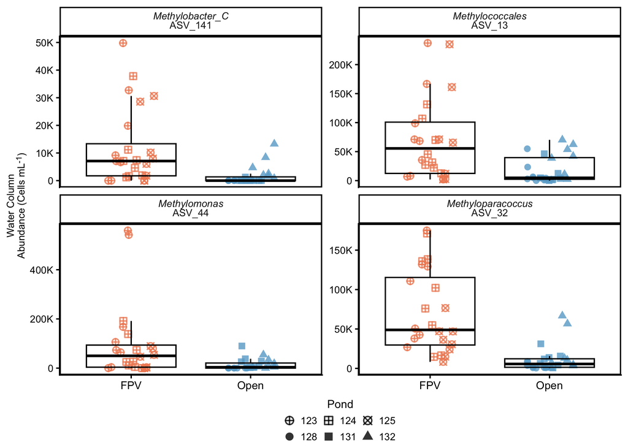

```r
# Make Boxplots of the ASVs!
diffAbund_boxplots <- diff_abund_df %>%
  ggplot(aes(x = solar_progress, y = total_abundance,
             color = solar_progress)) +
  geom_point(aes(shape = Pond),
             size = 2, alpha = 0.8, stroke = 0.8,
             position = position_jitterdodge(jitter.width = .5, dodge.width = .3)) +
  geom_boxplot(outlier.shape = NA, alpha = 0, color = "black", position = position_dodge(0.6)) +
  labs(color = "Treatment", y = "Water Column<br>Abundance (Cells mL<sup>-1</sup>)") +
  ggh4x::facet_wrap2(~ facet_label, scales = "free_y", nrow = 2) +
  # facet_grid2(~ facet_label, scales = "free_y",
  #             strip = strip_themed(text_x = element_markdown(size = 9, face = "plain")))+
  # facet_wrap2(~ facet_label, scales = "free_y", nrow = 2,
  #             strip = strip_themed(text_x = element_markdown(size = 10, face = "plain")))+
  #facet_wrap2(~italicized_label, scales = "free_y", nrow = 2, labeller = label_parsed) +
  scale_color_manual(values = solar_colors) +
  scale_shape_manual(values = pond_shapes) +
  scale_y_continuous(labels = label_number(scale_cut = cut_short_scale(), accuracy = 1)) +
  theme_classic() +
  # stat_compare_means(method = "wilcox.test",
  #                    #comparisons = list(c("FPV", "Open")),
  #                    label = "p.format",
  #                    #group.by = "combined_label",
  #                    size = 3,
  #                    label.y.npc = 0.9,
  #                    fontface = "italic",
  #                    #label.y = c(8000, 100000, 500000, 400000, 400000),
  #                    label.x = c(1.75, 1.75, 1.75)) +
  guides(
    color = "none",
    # color = guide_legend(
    #   order = 1,
    #   ncol= 2,
    #   title.position = "top",
    #   title.hjust = 0.5,
    #   override.aes = list(size = 2.5)),
    shape = guide_legend(
      nrow= 2,
      byrow = TRUE,
      title.position = "top",
      title.hjust = 0.5,
      override.aes = list(size = 2.5))) +
  theme_classic() +
  theme( #legend.position = c(0.75, 0.7),
    legend.position = "bottom",
        legend.spacing = unit(0, "cm"),
        plot.title = element_text(hjust = 0.5),
        panel.background =  element_rect(color = 'black', size = 1),
        panel.grid = element_blank(),
        legend.background = element_rect(fill = "transparent", color = NA), # remove legend box
        legend.key = element_rect(fill = "transparent", color = NA),
        legend.box.background = element_rect(fill='transparent', color = "transparent"), #transparent legend panel
        legend.box.just = "center",
        #strip.background = element_rect(colour = NA, fill = 'transparent'),
        plot.background = element_rect(fill = "transparent", color="transparent"),
        legend.key.size = unit(0.2, "cm"),
        legend.spacing.x = unit(0.2, "cm"),
       legend.margin = margin(t = -5, unit = "pt"),
        strip.text = element_markdown(size = 8),
       axis.title.y = element_markdown(size = 8, colour = "black"),
       axis.title.x = element_blank(),
       axis.text.y = element_text(size = 8, colour = "black"),
       legend.title = element_text(size = 9, colour = "black"),
      legend.text = element_text(size = 8, colour = "black")); diffAbund_boxplots
```

```r
# # get legend
# legend <- cowplot::get_plot_component(diffAbund_boxplots, "guide-box", return_all = TRUE)
# legend_full <- legend$grobs[[2]]


# Save the plot
ggsave(diffAbund_boxplots, width = 4.5, height = 4.5, dpi = 300,
        filename = "figures/Fig_4/Fig_4.png")

ggsave(diffAbund_boxplots, width = 4.5, height = 4.5, dpi = 300,
        filename = "figures/Fig_4/Fig_4.jpeg")

##### ASV_13 Methylococcales #####
#1. Run stats
# 1a. calculate abundances
asv_13_sum <- diff_abund_df %>%
  dplyr::filter(ASV == "ASV_13") %>%
  group_by(solar_progress, JDate) %>% #
  dplyr::summarize(sd_meth = sd(total_abundance),
                   mean_meth = mean(total_abundance),
                   .groups = "drop")
asv_13_sum
```

```
## # A tibble: 8 × 4
##   solar_progress JDate sd_meth mean_meth
##   <fct>          <dbl>   <dbl>     <dbl>
## 1 FPV              172  25268.    21225.
## 2 FPV              193  18873.    20898.
## 3 FPV              234  26462.    90344.
## 4 FPV              255  85699.   149533.
## 5 Open             172  16551.     8872
## 6 Open             193   3538.     4231.
## 7 Open             234  21567.    43551.
## 8 Open             255  25481.    19204.
```

```r
# 1b. linear mixed model
asv_13_data <- diff_abund_df %>%
  dplyr::filter(ASV == "ASV_13")
asv_13_data$Pond <- as.factor(asv_13_data$Pond)

asv_13_data_model <- lmerTest::lmer(total_abundance ~ solar_progress + JDate + (1|Pond), data = asv_13_data) # omitting jdate as term
summary(asv_13_data_model) #0.000119
```

```
## Linear mixed model fit by REML. t-tests use Satterthwaite's method ['lmerModLmerTest']
## Formula: total_abundance ~ solar_progress + JDate + (1 | Pond)
##    Data: asv_13_data
##
## REML criterion at convergence: 1104.6
##
## Scaled residuals:
##      Min       1Q   Median       3Q      Max
## -1.91818 -0.56794  0.03968  0.46054  2.99311
##
## Random effects:
##  Groups   Name        Variance  Std.Dev.
##  Pond     (Intercept) 0.000e+00     0
##  Residual             1.829e+09 42763
## Number of obs: 48, groups:  Pond, 6
##
## Fixed effects:
##                     Estimate Std. Error        df t value Pr(>|t|)
## (Intercept)        -128382.2    41198.1      45.0  -3.116 0.003187 **
## solar_progressOpen  -51535.6    12344.7      45.0  -4.175 0.000135 ***
## JDate                  931.5      188.6      45.0   4.940 1.12e-05 ***
## ---
## Signif. codes:  0 '***' 0.001 '**' 0.01 '*' 0.05 '.' 0.1 ' ' 1
##
## Correlation of Fixed Effects:
##             (Intr) slr_pO
## slr_prgrssO -0.150
## JDate       -0.977  0.000
## optimizer (nloptwrap) convergence code: 0 (OK)
## boundary (singular) fit: see help('isSingular')
```

```r
emmeans::emmeans(asv_13_data_model, pairwise ~ solar_progress) #0.0135
```

```
## $emmeans
##  solar_progress emmean   SE df lower.CL upper.CL
##  FPV             70500 8730  4    46264    94736
##  Open            18964 8730  4    -5271    43200
##
## Degrees-of-freedom method: kenward-roger
## Confidence level used: 0.95
##
## $contrasts
##  contrast   estimate    SE df t.ratio p.value
##  FPV - Open    51536 12300  4   4.175  0.0140
##
## Degrees-of-freedom method: kenward-roger
```

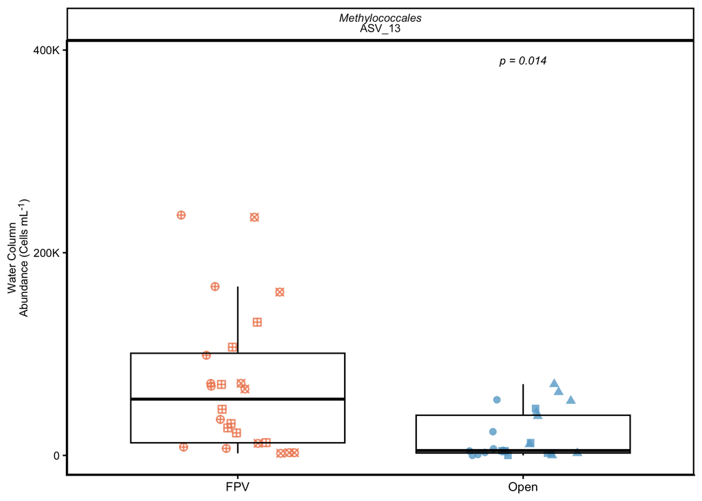

```r
# Make individual boxplots of the ASVs
ASV_13_methylococcales <- diff_abund_df %>%
  dplyr::filter(ASV == "ASV_13") %>%
  ggplot(aes(x = solar_progress, y = total_abundance,
             color = solar_progress)) +
  geom_point(aes(shape = Pond),
             size = 2, alpha = 0.8, stroke = 0.8,
             position = position_jitterdodge(jitter.width = .5, dodge.width = .3)) +
  geom_boxplot(outlier.shape = NA, alpha = 0, color = "black", position = position_dodge(0.6)) +
  labs(color = "Treatment", y = "Water Column<br>Abundance (Cells mL<sup>-1</sup>)") +
  # facet_grid2(~ facet_label, scales = "free_y",
  #             strip = strip_themed(text_x = element_markdown(size = 9, face = "plain")))+
  # ggh4x::facet_wrap2(~ facet_label, scales = "free_y", nrow = 2,
  #                    strip = strip_vanilla(clip = "on")) +
  ggh4x::facet_grid2(. ~ facet_label) +
  #facet_wrap2(~italicized_label, scales = "free_y", nrow = 2, labeller = label_parsed) +
  scale_color_manual(values = solar_colors) +
  scale_shape_manual(values = pond_shapes) +
  scale_y_continuous(
    breaks = c(0, 2e5, 4e5),
    labels = label_number(scale_cut = cut_short_scale(), accuracy = 1)) +
  # stat_compare_means(method = "wilcox.test",
  #                    #comparisons = list(c("FPV", "Open")),
  #                    label = "p.format",
  #                    #group.by = "combined_label",
  #                    size = 3,
  #                    label.y.npc = 0.9,
  #                    fontface = "italic",
  #                    #label.y = c(8000, 100000, 500000, 400000, 400000),
  #                    label.x = c(1.75, 1.75, 1.75)) +
  guides(
    # color = "none",
    color = guide_legend(
      #order = 1,
      ncol= 2,
      title.position = "top",
      title.hjust = 0.5,
      override.aes = list(size = 2.5)),
    shape = guide_legend(
      nrow= 2,
      byrow = TRUE,
      title.position = "top",
      title.hjust = 0.5,
      override.aes = list(size = 2.5))) +
  theme_classic() +
  theme(legend.position = "none",
        legend.spacing = unit(0, "cm"),
        plot.title = element_text(hjust = 0.5),
        panel.background =  element_rect(color = 'black', size = 1),
        panel.grid = element_blank(),
        legend.background = element_rect(fill = "transparent", color = NA), # remove legend box
        legend.key = element_rect(fill = "transparent", color = NA),
        legend.box.background = element_rect(fill='transparent', color = "transparent"), #transparent legend panel
        #legend.box.just = "center",
        #strip.background = element_rect(colour = NA, fill = 'transparent'),
        plot.background = element_rect(fill = "transparent", color="transparent"),
        legend.key.size = unit(0.4, "cm"),
        legend.spacing.x = unit(0.7, "cm"),
       legend.margin = margin(t = -5, unit = "pt"),
      strip.text = element_markdown(size = 8),
       axis.title.y = element_markdown(size = 8, colour = "black"),
       axis.title.x = element_blank(),
       axis.text.y = element_text(size = 8, colour = "black"),
       legend.title = element_text(size = 9, colour = "black"),
      legend.text = element_text(size = 8, colour = "black"))+
  annotate("text", x = 2, y = 3.9e5, label = "p = 0.014", size = 2.822,  fontface = "italic")
ASV_13_methylococcales
```

```r
##### ASV_32 Methylococcales #####
#1. Run stats
# 1a. calculate abundances
asv_32_sum <- diff_abund_df %>%
  dplyr::filter(ASV == "ASV_32") %>%
  group_by(solar_progress, JDate) %>% #
  dplyr::summarize(sd_meth = sd(total_abundance),
                   mean_meth = mean(total_abundance),
                   .groups = "drop")
asv_32_sum
```

```
## # A tibble: 8 × 4
##   solar_progress JDate sd_meth mean_meth
##   <fct>          <dbl>   <dbl>     <dbl>
## 1 FPV              172  22627.    34792.
## 2 FPV              193  58313.    76504.
## 3 FPV              234  56329.    82379.
## 4 FPV              255  58222.    89481.
## 5 Open             172  12319.     8318.
## 6 Open             193   5641.     8360.
## 7 Open             234  27779.    26197.
## 8 Open             255   2693.     2833.
```

```r
# 1b. linear mixed model
asv_32_data <- diff_abund_df %>%
  dplyr::filter(ASV == "ASV_32")
asv_32_data$Pond <- as.factor(asv_32_data$Pond)

asv_32_data_model <- lmerTest::lmer(total_abundance ~ solar_progress + JDate + (1|Pond), data = asv_32_data)
summary(asv_32_data_model) #0.0334
```

```
## Linear mixed model fit by REML. t-tests use Satterthwaite's method ['lmerModLmerTest']
## Formula: total_abundance ~ solar_progress + JDate + (1 | Pond)
##    Data: asv_32_data
##
## REML criterion at convergence: 1090.7
##
## Scaled residuals:
##      Min       1Q   Median       3Q      Max
## -1.62625 -0.64855 -0.08477  0.34187  2.35688
##
## Random effects:
##  Groups   Name        Variance  Std.Dev.
##  Pond     (Intercept) 3.507e+08 18726
##  Residual             1.205e+09 34715
## Number of obs: 48, groups:  Pond, 6
##
## Fixed effects:
##                     Estimate Std. Error        df t value Pr(>|t|)
## (Intercept)          7807.88   35148.73     43.84   0.222   0.8252
## solar_progressOpen -59362.12   18281.46      4.00  -3.247   0.0315 *
## JDate                 294.99     153.09     41.00   1.927   0.0609 .
## ---
## Signif. codes:  0 '***' 0.001 '**' 0.01 '*' 0.05 '.' 0.1 ' ' 1
##
## Correlation of Fixed Effects:
##             (Intr) slr_pO
## slr_prgrssO -0.260
## JDate       -0.930  0.000
```

```r
emmeans::emmeans(asv_32_data_model, pairwise ~ solar_progress) #0.0334
```

```
## $emmeans
##  solar_progress emmean    SE df lower.CL upper.CL
##  FPV             70789 12900  4    34898   106680
##  Open            11427 12900  4   -24464    47318
##
## Degrees-of-freedom method: kenward-roger
## Confidence level used: 0.95
##
## $contrasts
##  contrast   estimate    SE df t.ratio p.value
##  FPV - Open    59362 18300  4   3.247  0.0315
##
## Degrees-of-freedom method: kenward-roger
```

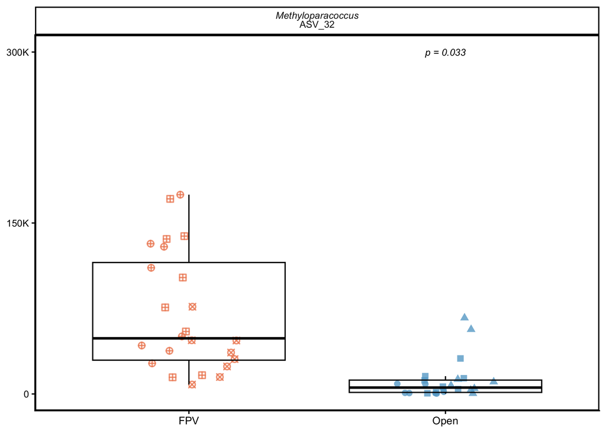

```r
# Make individual boxplots of the ASVs
ASV_32_methyloparacoccus <- diff_abund_df %>%
  dplyr::filter(ASV == "ASV_32") %>%
  ggplot(aes(x = solar_progress, y = total_abundance,
             color = solar_progress)) +
  geom_point(aes(shape = Pond),
             size = 2, alpha = 0.8, stroke = 0.8,
             position = position_jitterdodge(jitter.width = .5, dodge.width = .3)) +
  geom_boxplot(outlier.shape = NA, alpha = 0, color = "black", position = position_dodge(0.6)) +
  labs(color = "Treatment", y = "Water Column<br>Abundance (Cells mL<sup>-1</sup>)") +
  # facet_wrap2(~ facet_label, scales = "free_y", nrow = 2,
  #             strip = strip_themed(text_x = element_markdown(size = 9, face = "plain")))+
  # ggh4x::facet_wrap2(~ facet_label, scales = "free_y", nrow = 2,
  #                    strip = strip_vanilla(clip = "on")) +
  ggh4x::facet_grid2(. ~ facet_label) +
  #facet_wrap2(~italicized_label, scales = "free_y", nrow = 2, labeller = label_parsed) +
  scale_color_manual(values = solar_colors) +
  scale_shape_manual(values = pond_shapes) +
  scale_y_continuous(
    breaks = c(0, 1.5e5, 3e5),
    labels = label_number(scale_cut = cut_short_scale(), accuracy = 1)) +
  theme_classic() +
  # stat_compare_means(method = "wilcox.test",
  #                    #comparisons = list(c("FPV", "Open")),
  #                    label = "p.format",
  #                    #group.by = "combined_label",
  #                    size = 3,
  #                    label.y.npc = 0.9,
  #                    fontface = "italic",
  #                    #label.y = c(8000, 100000, 500000, 400000, 400000),
  #                    label.x = c(1.75, 1.75, 1.75)) +
  guides(
    #color = "none",
    color = guide_legend(
      #order = 1,
      ncol= 2,
      title.position = "top",
      title.hjust = 0.5,
      override.aes = list(size = 2.5)),
    shape = guide_legend(
      nrow= 2,
      byrow = TRUE,
      title.position = "top",
      title.hjust = 0.5,
      override.aes = list(size = 2.5))) +
  theme(legend.position = "none",
        legend.spacing = unit(0, "cm"),
        plot.title = element_text(hjust = 0.5),
        panel.background =  element_rect(color = 'black', size = 1),
        panel.grid = element_blank(),
        legend.background = element_rect(fill = "transparent", color = NA), # remove legend box
        legend.key = element_rect(fill = "transparent", color = NA),
        legend.box.background = element_rect(fill='transparent', color = "transparent"), #transparent legend panel
        #legend.box.just = "center",
        #strip.background = element_rect(colour = NA, fill = 'transparent'),
        plot.background = element_rect(fill = "transparent", color="transparent"),
        legend.key.size = unit(0.4, "cm"),
        legend.spacing.x = unit(0.7, "cm"),
        legend.margin = margin(t = -5, unit = "pt"),
        strip.text = element_markdown(size = 8),
       #axis.title.y = element_markdown(size = 8, colour = "black"),
       axis.title.x = element_blank(),
       axis.title.y = element_blank(),
       axis.text.y = element_text(size = 8, colour = "black"),
       legend.title = element_text(size = 9, colour = "black"),
      legend.text = element_text(size = 8, colour = "black"))+
  annotate("text", x = 2, y = 3e5, label = "p = 0.033", size = 2.822,  fontface = "italic")
ASV_32_methyloparacoccus
```

```r
##### ASV_44 Methylomonas #####
#1. Run stats
# 1a. calculate abundances
asv_44_sum <- diff_abund_df %>%
  dplyr::filter(ASV == "ASV_44") %>%
  group_by(solar_progress, JDate) %>% #
  dplyr::summarize(sd_meth = sd(total_abundance),
                   mean_meth = mean(total_abundance),
                   .groups = "drop")
asv_44_sum
```

```
## # A tibble: 8 × 4
##   solar_progress JDate sd_meth mean_meth
##   <fct>          <dbl>   <dbl>     <dbl>
## 1 FPV              172  42706.    19082.
## 2 FPV              193  65613.    35134.
## 3 FPV              234  57859.    94634.
## 4 FPV              255 250714.   228125
## 5 Open             172  35791.    18546.
## 6 Open             193  13368.    10564.
## 7 Open             234  22744.    22425.
## 8 Open             255   2031.     2582
```

```r
# 1b. linear mixed model
asv_44_data <- diff_abund_df %>%
  dplyr::filter(ASV == "ASV_44")
asv_44_data$Pond <- as.factor(asv_44_data$Pond)

asv_44_data_model <- lmerTest::lmer(total_abundance ~ solar_progress + JDate + (1|Pond), data = asv_44_data)
summary(asv_44_data_model) #0.1708
```

```
## Linear mixed model fit by REML. t-tests use Satterthwaite's method ['lmerModLmerTest']
## Formula: total_abundance ~ solar_progress + JDate + (1 | Pond)
##    Data: asv_44_data
##
## REML criterion at convergence: 1179.8
##
## Scaled residuals:
##     Min      1Q  Median      3Q     Max
## -1.4293 -0.4013 -0.1500  0.2860  3.7755
##
## Random effects:
##  Groups   Name        Variance  Std.Dev.
##  Pond     (Intercept) 2.466e+09 49660
##  Residual             8.747e+09 93524
## Number of obs: 48, groups:  Pond, 6
##
## Fixed effects:
##                      Estimate Std. Error         df t value Pr(>|t|)
## (Intercept)        -141818.80   94552.27      43.96  -1.500   0.1408
## solar_progressOpen  -80714.75   48713.09       4.00  -1.657   0.1729
## JDate                 1105.68     412.44      41.00   2.681   0.0105 *
## ---
## Signif. codes:  0 '***' 0.001 '**' 0.01 '*' 0.05 '.' 0.1 ' ' 1
##
## Correlation of Fixed Effects:
##             (Intr) slr_pO
## slr_prgrssO -0.258
## JDate       -0.931  0.000
```

```r
emmeans::emmeans(asv_44_data_model, pairwise ~ solar_progress) #0.1708
```

```
## $emmeans
##  solar_progress emmean    SE df lower.CL upper.CL
##  FPV             94244 34400  4    -1392   189880
##  Open            13529 34400  4   -82106   109165
##
## Degrees-of-freedom method: kenward-roger
## Confidence level used: 0.95
##
## $contrasts
##  contrast   estimate    SE df t.ratio p.value
##  FPV - Open    80715 48700  4   1.657  0.1729
##
## Degrees-of-freedom method: kenward-roger
```

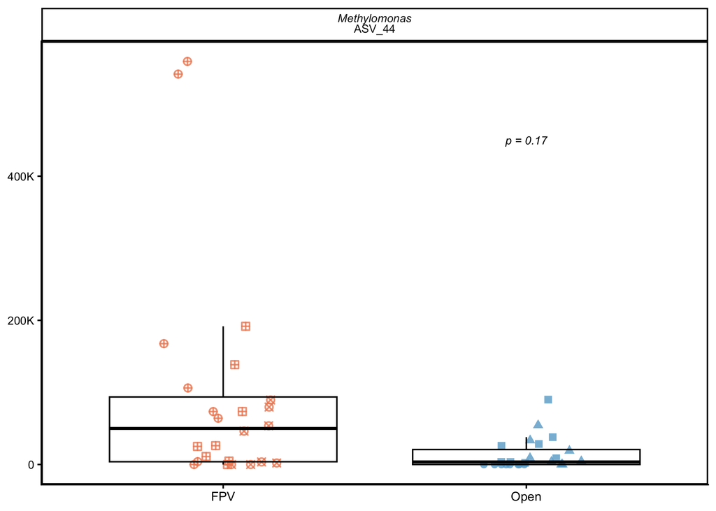

```r
# Make individual boxplots of the ASVs
ASV_44_methylomonas <- diff_abund_df %>%
  dplyr::filter(ASV == "ASV_44") %>%
  ggplot(aes(x = solar_progress, y = total_abundance,
             color = solar_progress)) +
  geom_point(aes(shape = Pond),
             size = 2, alpha = 0.8, stroke = 0.8,
             position = position_jitterdodge(jitter.width = .5, dodge.width = .3)) +
  geom_boxplot(outlier.shape = NA, alpha = 0, color = "black", position = position_dodge(0.6)) +
  labs(color = "Treatment", y = "Water Column<br>Abundance (Cells mL<sup>-1</sup>)") +
  # ggh4x::facet_wrap2(~ facet_label, scales = "free_y", nrow = 2,
  #             strip = ggh4x::strip_themed(text_x = list(
  #               ggtext::element_markdown(size = 9, face = "plain"))))+
  ggh4x::facet_wrap2(~ facet_label, scales = "free_y", nrow = 2) +
  #facet_wrap2(~italicized_label, scales = "free_y", nrow = 2, labeller = label_parsed) +
  scale_color_manual(values = solar_colors) +
  scale_shape_manual(values = pond_shapes) +
  scale_y_continuous(
    breaks = c(0, 2e5, 4e5),
    labels = label_number(scale_cut = cut_short_scale(), accuracy = 1)) +
  theme_classic() +
  # stat_compare_means(method = "wilcox.test",
  #                    #comparisons = list(c("FPV", "Open")),
  #                    label = "p.format",
  #                    #group.by = "combined_label",
  #                    size = 3,
  #                    label.y.npc = 0.9,
  #                    fontface = "italic",
  #                    #label.y = c(8000, 100000, 500000, 400000, 400000),
  #                    label.x = c(1.75, 1.75, 1.75)) +
  guides(
    color = "none",
    color = guide_legend(
      order = 1,
      ncol= 2,
      title.position = "top",
      title.hjust = 0.5,
      override.aes = list(size = 2.5)),
    shape = guide_legend(
      nrow= 2,
      byrow = TRUE,
      title.position = "top",
      title.hjust = 0.5,
      override.aes = list(size = 2.5))) +
  theme_classic() +
  theme(legend.position = "none",
        legend.spacing = unit(0, "cm"),
        plot.title = element_text(hjust = 0.5),
        panel.background =  element_rect(color = 'black', size = 1),
        panel.grid = element_blank(),
        legend.background = element_rect(fill = "transparent", color = NA), # remove legend box
        legend.key = element_rect(fill = "transparent", color = NA),
        legend.box.background = element_rect(fill='transparent', color = "transparent"), #transparent legend panel
        legend.box.just = "center",
        #strip.background = element_rect(colour = NA, fill = 'transparent'),
        plot.background = element_rect(fill = "transparent", color="transparent"),
        legend.key.size = unit(0.4, "cm"),
        legend.spacing.x = unit(0.2, "cm"),
      # legend.margin = margin(t = -5, unit = "pt"),
        strip.text = element_markdown(size = 8),
       #axis.title.y = element_markdown(size = 8, colour = "black"),
       axis.title.x = element_blank(),
       axis.title.y = element_blank(),
       axis.text.y = element_text(size = 8, colour = "black"),
       legend.title = element_text(size = 9, colour = "black"),
      legend.text = element_text(size = 8, colour = "black"))+
  annotate("text", x = 2, y = 4.5e5, label = "p = 0.17", size = 2.822,  fontface = "italic")
ASV_44_methylomonas
```

```r
##### ASV_141 Methylobacter_C #####
#1. Run stats
# 1a. calculate abundances
asv_141_sum <- diff_abund_df %>%
  dplyr::filter(ASV == "ASV_141") %>%
  group_by(solar_progress, JDate) %>% #
  dplyr::summarize(sd_meth = sd(total_abundance),
                   mean_meth = mean(total_abundance),
                   .groups = "drop")
asv_141_sum
```

```
## # A tibble: 8 × 4
##   solar_progress JDate sd_meth mean_meth
##   <fct>          <dbl>   <dbl>     <dbl>
## 1 FPV              172   3650.     3620.
## 2 FPV              193  22512.    15170.
## 3 FPV              234  11294.    15208.
## 4 FPV              255  11307.    13213.
## 5 Open             172    340.      139.
## 6 Open             193   3362.     1662
## 7 Open             234   1135.      973.
## 8 Open             255   5376.     2996.
```

```r
# 1b. linear mixed model
asv_141_data <- diff_abund_df %>%
  dplyr::filter(ASV == "ASV_141")
asv_141_data$Pond <- as.factor(asv_141_data$Pond)

asv_141_data_model <- lmerTest::lmer(total_abundance ~ solar_progress + JDate + (1|Pond), data = asv_141_data)
summary(asv_141_data_model) #0.000914 ***
```

```
## Linear mixed model fit by REML. t-tests use Satterthwaite's method ['lmerModLmerTest']
## Formula: total_abundance ~ solar_progress + JDate + (1 | Pond)
##    Data: asv_141_data
##
## REML criterion at convergence: 973.7
##
## Scaled residuals:
##     Min      1Q  Median      3Q     Max
## -1.3076 -0.5908 -0.1594  0.0996  3.9253
##
## Random effects:
##  Groups   Name        Variance Std.Dev.
##  Pond     (Intercept)        0    0
##  Residual             99685682 9984
## Number of obs: 48, groups:  Pond, 6
##
## Fixed effects:
##                     Estimate Std. Error        df t value Pr(>|t|)
## (Intercept)          -737.30    9618.83     45.00  -0.077 0.939241
## solar_progressOpen -10359.96    2882.21     45.00  -3.594 0.000803 ***
## JDate                  58.73      44.03     45.00   1.334 0.188927
## ---
## Signif. codes:  0 '***' 0.001 '**' 0.01 '*' 0.05 '.' 0.1 ' ' 1
##
## Correlation of Fixed Effects:
##             (Intr) slr_pO
## slr_prgrssO -0.150
## JDate       -0.977  0.000
## optimizer (nloptwrap) convergence code: 0 (OK)
## boundary (singular) fit: see help('isSingular')
```

```r
emmeans::emmeans(asv_141_data_model, pairwise ~ solar_progress) #0.0238
```

```
## $emmeans
##  solar_progress emmean   SE df lower.CL upper.CL
##  FPV             11803 2040  4     6144    17461
##  Open             1443 2040  4    -4216     7101
##
## Degrees-of-freedom method: kenward-roger
## Confidence level used: 0.95
##
## $contrasts
##  contrast   estimate   SE df t.ratio p.value
##  FPV - Open    10360 2880  4   3.594  0.0229
##
## Degrees-of-freedom method: kenward-roger
```